# **Python Tutorial - MIS346**

# How Python Works

A Python program starts as a text file written in a code editor, saved with a **.py extension**. The Python interpreter reads this source code, analyzes it, and executes it line by line. During this process, it performs lexical analysis, parsing, and execution.

[figure not shown]

# First Python Code

```python
!python --version
```

```
Python 3.11.11
```

```python
!which python
```

```
/usr/local/bin/python
```

```python
print("Hello World")
```

```
Hello World
```

```python
print("Hello", "World")
```

```
Hello World
```

# Python Variables

Seven data types supported by Python:

1. Numbers -> `age=10 or weight:94.5` *integer or float
2. Booleans -> `is_married=True, is_open=False` *True or False
3. Strings -> `name="Güray"`
4. Lists -> `numbers=[1,3,2] fruits=['apple', 'banana']` *mutable-changable
5. Tuples -> `cars=('Toyota', "TOGG')` *immutable
6. Sets -> `student_ids={1234, 2345, 6897}` *unique values
7. Dictionary -> `{"name":"Güray", "age":45}` * key:value pairs

A **variable is a name for a location in memory** that references an object and allows us to associate labels with objects.

A variable has three things:

◦ a label : that is how we refer to it

◦ a type : what kind of a thing is stored in the box

◦ a value : what is in the box

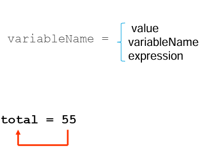

```python
total = 55
```

## Numbers

```python
age = 45 #integer number

weight= 94.5 # float number
```

```python
print(type(age), type(weight))
```

```
<class 'int'> <class 'float'>
```

```python
new_age = age + 10 #snake syntax
print(new_age)
```

```
55
```

```python
result =age * weight
print(result)
```

```
4252.5
```

```python
result = weight / age
print(result)
```

```
2.1
```

```python
print(type(result))
```

```
<class 'float'>
```

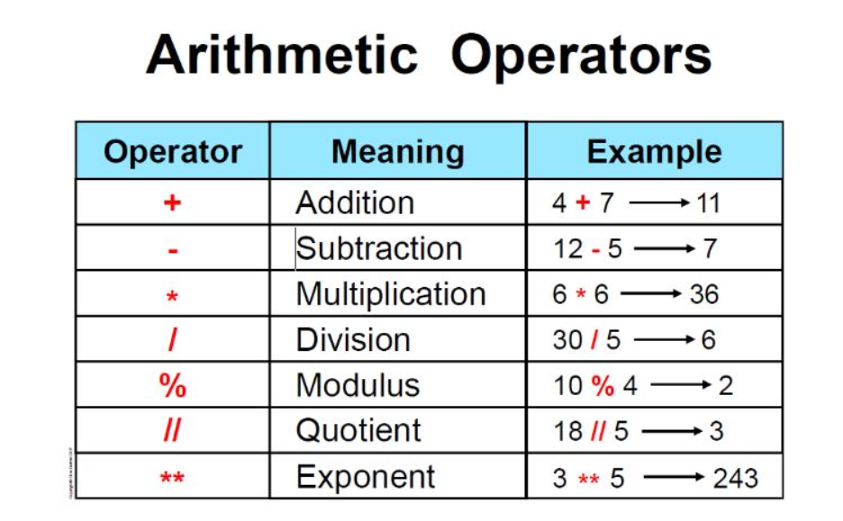

## Multiple assignments

```python
x, y = 10, 20
```

```python
print(x)
```

```
10
```

```python
print(y)
```

```
20
```

## Changing bindings

In python **you can re-bind variable names using new assignment statements**. The previous value may still be stored in memory but the reference to the value no longer exists.

Value for area does not change until you tell the computer to do the calculation again.

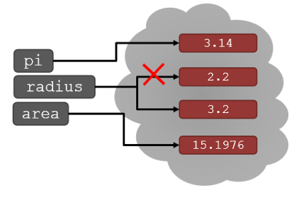

```python
pi = 3.14
radius = 2.2
area = pi*(radius**2)
print("area: ", area)
radius = radius+1
```

```
area:  15.197600000000003
```

## Boolean

**bool** –represent two Boolean values **True** and **False**

In programming you often need to know if an expression is True or False.

You can evaluate any expression in Python, and get one of two answers, **True or False**.

**When you compare two values**, the expression is evaluated and Python returns the Boolean answer:

```python
print(10 > 9)
print(10 == 9)
print(10 < 9)
```

```
True
False
False
```

```python
is_married=True
type(is_married)
```

```
bool
```

The **bool()** function allows you to evaluate any value, and give you True or False in return

```python
print(bool("Hello"))
print(bool(15))
```

```
True
True
```

**Most Values are True** Almost any value is evaluated to True if it has some sort of content.

**Any string is True, except empty strings.**

**Any number is True, except 0.**

**Any list, tuple, set, and dictionary are True, except empty ones.**

```python
print(bool("abc"))
print(bool(123))
print(bool(["apple", "cherry", "banana"]))
```

```
True
True
True
```

```python
bool(False)
bool(None)
bool(0)
bool("")
bool(())
bool([])
bool({})
```

```
False
```

## Type conversion

Sometimes we need to convert data from one type to another.

For example, we may want to find the integer value of 3.2.

We can use built in functions to convert object of one type to another (type casting)

◦ **float(3)** converts integer 3 to float 3.0

◦ **int(3.9)** truncates float 3.9 to integer 3

◦ **bool(5)**converts non zero values to boolean True

◦ **bool(0)**converts zero value to boolean False

```python
age=45
print(age)

age_str=str(age)
print(type(age_str))
```

```
45
<class 'str'>
```

```python
weight=95.45
print(weight)

print(int(weight))
```

```
95.45
95
```

## Strings

```python
name='Güray'

surname = "ARIK"
```

```python
print(type(name), type(surname))
```

```
<class 'str'> <class 'str'>
```

```python
print(name, surname)
```

```
Güray ARIK
```

```python
print (f"{name} {surname}")
```

```
Güray ARIK
```

```python
name= input("Enter your name: ")
surname = input("Enter your surname: ")

print(name, surname)
```

## String Functions

Python has a set of built-in methods that you can use on strings.

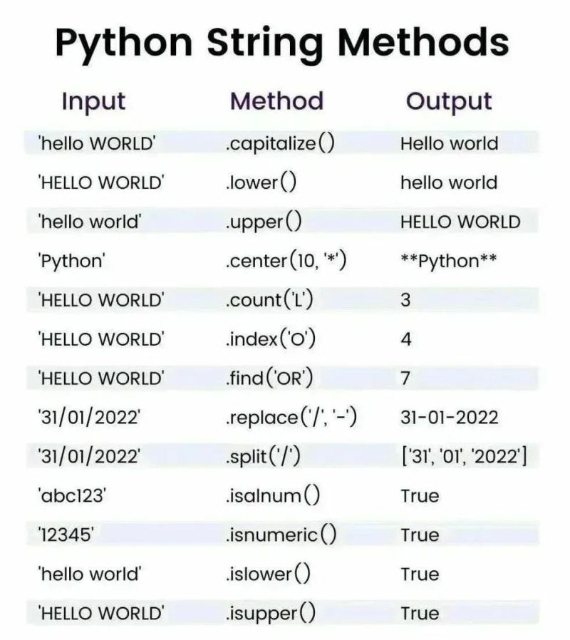

```python
print(name)
```

```python
print(name.upper())
```

```python
print(name.find("ü"))
```

```python
len(name)
```

## String Slicing

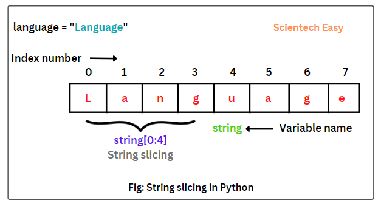

```python
str_value="Language"
```

```python
#str_value[start_index:end_index:step]
str_value[0:4]
```

```python
str_value[0:8]
```

```python
str_value[ : 8 ]
```

```python
str_value[:8]
```

```python
str_value[:]
```

```python
str_value[:-1]
```

```python
#put steps
str_value[0:8:1]
```

```python
str_value[0:8:2]
```

## Comments

Comments explain the purpose and process. **Comments are not interpreted and do not affect program execution**. Python comments can take two forms:

# single line comment

""" multi-line comment,

continues to end symbol,

across line breaks """

Comments should describe ‘why’ rather than how. Multi-line comments are also called docstrings. Docstrings provide documentation for functions, modules and classes which we will discuss later.

```python
#single line comment
""" multi-line comment,
continues to end symbol,
across line breaks """
print("hello") # just this line works
```

## Formatting Strings

To format numeric or string values, use **f-strings** Syntax:

f’string to be formatted’ ’string to be formatted’ includes format fields, enclosed in curly braces {…}

```python
salary=50000.2248
print("Your salary is", salary)
```

```python
salary = 50000.2248
print(f'Your salary is {salary:.3f}')
```

## Exercises

**Exercise 1.** Write a program that converts 300K to Celsius and displays the formatted result.

```python
kelvin_value=300
celcius=kelvin_value-273
print(f"{kelvin_value} K is equal to {celcius:.2f} C")
```

**Exercise 2.** Write a program that finds the **area and perimeter of a circle** with the radius 2.5 cm and display the result. You can assume pi is the constant value 3.14.

```python
radius = 2.5
pi = 3.14
# Area = π * r^2
area = pi * (radius ** 2)

# Perimeter (Circumference) = 2 * π * r
perimeter = 2 * pi * radius

print(f"Area: {area:.2f} cm²")
print(f"Perimeter: {perimeter:.2f} cm")
```

**Exercise 3.** Write a program that finds the sum of the first and last digit of some 4 digit number.

```python
number = 2025  # Example 4-digit number

# Convert number to string to extract digits
number_str = str(number)
first_digit = int(number_str[0])
last_digit = int(number_str[-1])

sum_of_digits = first_digit + last_digit
print(f"The sum of the first {first_digit} and last digit {last_digit} of {number} is {sum_of_digits}")
```

**Exercise 4.** Write a program to calculate the number of hours and minutes needed for a car to travel 800 kilometers at the velocity 120 km/h.

```python
distance = 800
velocity = 120

# Time = Distance / Velocity
time_hours = distance / velocity

# Convert time to hours and minutes
hours = int(time_hours)
minutes = int((time_hours - hours) * 60)

print(f"Time needed to travel {distance} km at {velocity} km/h is {hours} hours and {minutes} minutes.")
```

# **Branching** (if statements)

Python supports the usual logical conditions from mathematics:

Equals: a == b

Not Equals: a != b

Less than: a < b

Less than or equal to: a <= b

Greater than: a > b

Greater than or equal to: a >= b

These conditions can be used in several ways, most commonly in "if statements" and loops.

An "if statement" is written by using the if keyword.

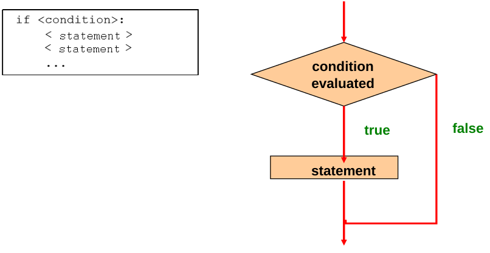

```python
a = 10
b = 20
if b > a:
  print("b is greater than a")
```

```
b is greater than a
```

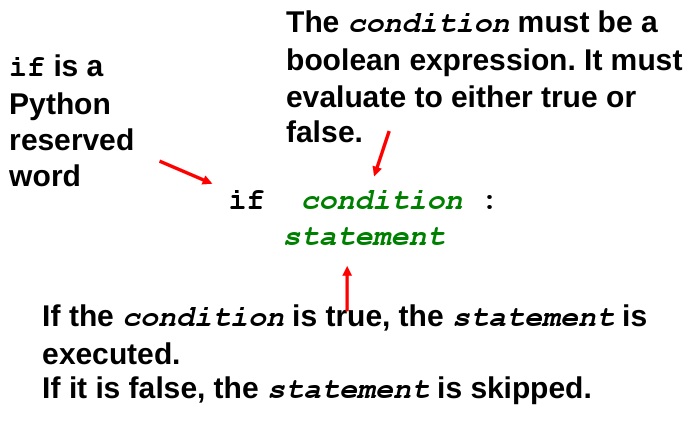

```python
num=int(input("Enter a number: "))

if(num == 0) :
  print ('num is zero') #non-zero values evaluate to True
elif(num %2 != 0):
  print ('num is odd')
else:
  print ('num is even')
```

```
Enter a number: 7
num is odd
```

## Elif

The elif keyword is Python's way of saying "if the previous conditions were not true, then try this condition".

```python
a = 30
b = 30
if b > a:
  print("b is greater than a")
elif a == b:
  print("a and b are equal")

print(x)
```

[output not shown]

```python
num=int(input("Enter a number: "))

if(num % 2) == 0 :
  print ('num is even')
else:
  print ('num is odd')
```

```
Enter a number: 15
num is odd
```

```python
x , y = 2 , 3
if x > y:
  print('x is larger')
else:
  print('x is not larger')
print('Done')
```

```
x is not larger
Done
```

## Else

The else keyword catches anything which isn't caught by the preceding conditions.

```python
a = 200
b = 33
if b > a:
  print("b is greater than a")
elif a == b:
  print("a and b are equal")
else:
  print("a is greater than b")
```

```python
age=int(input("Enter your age: "))

if age < 18:
  print ('You can not drive, you are too young')
elif (age >= 18 and age < 80):
  print ('You can drive')
else:
  print ('You can not drive, you are old')
```

```
Enter your age: 15
You can not drive, you are too young
```

## Short Hand If ... Else

If you have only one statement to execute, one for if, and one for else, you can put it all on the same line:

This technique is known as **Ternary Operators**, or **Conditional Expressions**.

```python
a = 30
b = 30
if b > a:
  print("b is greater than a")
else:
  print("a and b are equal")


a = 10
b = 20
print("A") if a > b else print("B")
```

[output not shown]

```python
num=int(input("Enter a number: "))
print('num is even') if num % 2==0 else print("num is odd")
```

```
Enter a number: 10
num is even
```

## Exercises

**Exercise 1**: Ask the user for a number. If that number is evenly divisible by either 3 or 5, print a message stating that the number is divisible by 3 or 5, including the number itself in the message.

```python
number = int(input("Enter a number: "))
if number % 3 == 0 or number % 5 == 0:
    print(f"{number} is divisible by 3 or 5")
```

```
Enter a number: 15
15 is divisible by 3 or 5
```

**Exercise 2:** The computer will pick a secret number between 1 and 9 (use random library). Ask the user to guess what that number is. If the user guesses the correct number, print "Well guessed!". If the user guesses the wrong number, print "Wrong Guess!".

```python
import random

secret_number = random.randint(1, 9)
guess = int(input("Guess a number between 1 and 9: "))

if guess == secret_number:
    print("Well guessed!")
else:
    print("Wrong Guess!")
```

```
Guess a number between 1 and 9: 7
Well guessed!
```

### Random library

The **random** library in Python is a module that provides functions for generating pseudo-random numbers.

It's a crucial tool for introducing randomness into your programs for various purposes, such as simulations, games, security, and data analysis

**Key Functions in the random Library:**

**random.random()**:

Returns a random floating-point number between 0.0 (inclusive) and 1.0 (exclusive). This is the most basic random number generator.

**random.randint(a, b)**:

Returns a random integer between a and b (inclusive). Both a and b must be integers.

This is often used when you need a random whole number within a specific range.

**How to use it:**

1. Import the library:

```python
import random
```

1. Call the functions:

```python
# Generate a random float between 0 and 1
random_float = random.random()
print(random_float)

# Generate a random integer between 1 and 10
random_integer = random.randint(1, 10)
print(random_integer)
```

```
0.6766994874229113
9
```

**random.seed(x):**

```python
random.seed(42)
# Generate a random float between 0 and 1
random_float = random.random()
print(random_float)

# Generate a random integer between 1 and 10
random_integer = random.randint(1, 10)
print(random_integer)
```

```
0.6394267984578837
1
```

**Exercise 3:** Ask the user to type in a word.

- Check if the **first letter and the last letter of the word are the same**.
- If they are the same, tell the user that the word starts and ends with the same letter.
- If they are different, tell the user that the word does not start and end with the same letter.

```python
word = input("Enter a word: ")

if len(word) > 0 and word[0] == word[-1]:
  print("The word has the same letter at the beginning and the end.")
else:
  print("The word does not have the same letter at the beginning and the end.")
```

```
Enter a word: güray
The word does not have the same letter at the beginning and the end.
```

**Exercise 4:** Ask the user for their **height** (in meters) and their **weight** (in kilograms). Then, calculate their **BMI** (Body Mass Index).

- If the **BMI** is **30 or higher**, tell them they are **Obese**.
- If the **BMI** is **25 or higher**, but **less than 30**, tell them they are **Overweight**.
- If the **BMI** is **20 or higher**, but **less than 25**, tell them they are **Normal**.
- If the **BMI** is **less than 20**, tell them they are **Underweight**.

```python
height = float(input("Enter your height in meters: "))
weight = float(input("Enter your weight in kgs: "))

bmi = weight / (height ** 2)

if bmi >= 30:
    print("Obese")
elif 25 <= bmi < 30:
    print("Overweight")
elif 20 <= bmi < 25:
    print("Normal")
else:
    print("Underweight")
```

```
Enter your height in meters: 1.85
Enter your weight in kgs: 95
Overweight
```

# Loops

Repetition statements allow us to execute a statement multiple times.

Often, they are referred to as loops Like conditional statements.

They may be controlled by Boolean expressions Python has two kinds of repetition statements: for and while loops

## For loops

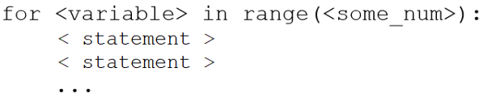

```python
for i in range(1,11):
  print(i ** 2)
```

```
1
4
9
16
25
36
49
64
81
100
```

**range(start,stop,step)**

The range function generates a list of numbers, generally used to iterate with for loops.

The function has 3 parameters:

◦ **start**: starting number of the sequence

◦ **stop**: generate numbers up to but not including the stopping value

◦ **step**: update/difference between each number in the sequence.

default values are start = 0 and step = 1 loop until value is stop – 1, inclusive

```python
x=6

for i in range(x):
  print(i)
```

```
0
1
2
3
4
5
```

```python
x=6

for i in range(0, x):
  print(i)
```

```
0
1
2
3
4
5
```

```python
x=6

for i in range(0, x, 1):
  print(i)
```

```
0
1
2
3
4
5
```

```python
name="Güray"
for char in name:
  print(char)
```

```
G
ü
r
a
y
```

## break

The **break** statement is used to immediately exit whatever loop it is in.

**Break skips remaining expressions in code block**.

Break exits only containing loop!

```python
for i in range(1, 11):

  if i == 7:
    break
  print(i)
```

```
1
2
3
4
5
6
```

## while

With the while loop we can execute a set of statements as long as a condition is true.

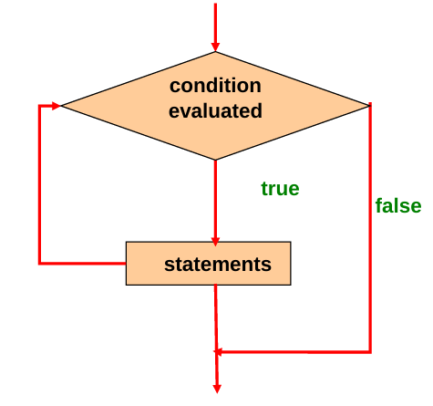

```python
i = 1
while i < 6:
  print(i)
  i += 1
```

```
1
2
3
4
5
```

```python
#while with break statement
i = 1
while i < 6:
  print(i)
  if i == 3:
    break
  i += 1
```

```
1
2
3
```

## continue

With the **continue** statement we can stop the current iteration, and continue with the next:

```python
i = 0
while i < 6:
  i += 1
  if i == 3:
    continue
  print(i)
```

```
1
2
4
5
6
```

## while with else

With the else statement we can run a block of code once when the condition no longer is true:

```python
i = 1
while i < 6:
  print(i)
  i += 1
else:
  print("i is no longer less than 6")
```

```
1
2
3
4
5
i is no longer less than 6
```

## for VS while LOOPS

**for loops:**

◦ know number of iterations

◦ can end early via break

◦ uses a counter

◦ can rewrite a for loop using a while loop

**while loops:**

◦ unbounded number of iterations

◦ can end early via break

◦ can use a counter but must initialize before loop and increment it inside loop

◦ may not be able to rewrite a while loop using a for loop

## Nested Loops

```python
for i in range(1,6,2):
  for j in range(6, 0, -3):
    print("i = " + str(i) + "\tj = " + str(j))
```

```
i = 1	j = 6
i = 1	j = 3
i = 3	j = 6
i = 3	j = 3
i = 5	j = 6
i = 5	j = 3
```

```python
#a program that prints a triangle of stars:
for i in range(1, 6):
  for j in range(i):
    print("*", end="")
  print()
```

## Exercises

**Exercise 1:** You put 10000 TL in a bank. The bank gives you 15% extra each year. How many years until you have at least 20000 TL?

```python
money = 10000
target = 20000
rate = 0.15   # Interest rate (15%)
years = 0     # Start counting years

while money < target:
    money = money + (money * rate) # Add interest
    years = years + 1               # Count the year

print("It takes", years, "years to double your money.")
```

```
It takes 5 years to double your money.
```

```python
money = 10000
target = 20000
rate = 0.15   # Interest rate (15%)
years = 0     # Start counting years

for years in range(1, 100): #loop for max 100 years
    money = money + (money * rate) # Add interest
    if money >= target:
        print("It takes", years, "years to double your money.")
        break
```

**Exercise 2:** Ask the user to type in positive numbers, one at a time. When they type in a negative number, stop asking. Then, calculate the average of all the positive numbers they typed in.

```python
total = 0
count = 0
number = 0

while True: # Keep asking until the user enters a negative number
    number = int(input("Enter a positive number (negative number to stop): "))
    if number < 0:
        break  # Stop the loop
    total = total + number
    count = count + 1

if count > 0:  # Make sure we have some numbers
    average = total / count
    print("The average is", average)
else:
    print("No positive numbers were entered.")
```

```
Enter a positive number (negative number to stop): 5
Enter a positive number (negative number to stop): 3
Enter a positive number (negative number to stop): 2
Enter a positive number (negative number to stop): -1
The average is 3.3333333333333335
```

```python
total = 0
count = 0
num_inputs = int(input("How many numbers will you enter? ")) # Get the number of input from the user

print("Enter", num_inputs, "positive numbers (or a negative number to stop).")

for _ in range(num_inputs): # Loop for specific num of times
    number = float(input("Enter a number: "))
    if number < 0:
      print("Negative number entered. Stopping input.")
      break # exit loop immediately
    total += number
    count += 1

if count > 0:
    average = total / count
    print("The average of the positive numbers is:", average)
else:
    print("No positive numbers were entered.")
```

**Exercise 3:** The computer picks a secret number between 1 and 10. You try to guess it. The computer tells you how many tries it took.

```python
import random

secret_number = random.randint(1, 10)
guesses = 0 #how many guesses does it take

while True:
    guess = int(input("Guess a number between 1 and 10: "))
    guesses = guesses + 1
    if guess == secret_number:
        print("You guessed it! It took you", guesses, "tries.")
        break #Correct guess, exit from loop
    else:
        print("Wrong guess. Try again.")
```

```
Guess a number between 1 and 10: 4
Wrong guess. Try again.
Guess a number between 1 and 10: 5
Wrong guess. Try again.
Guess a number between 1 and 10: 6
Wrong guess. Try again.
Guess a number between 1 and 10: 7
You guessed it! It took you 4 tries.
```

```python
import random

secret_number = random.randint(1, 10)
tries = 0
guess = 0

print("I'm thinking of a number between 1 and 10.")

for tries in range(1, 11):  # Limit to 10 tries maximum
    try:
        guess = int(input("Take a guess: "))

        if guess < 1 or guess > 10:
            print("Please guess a number between 1 and 10.")
            continue  # Go to the next iteration of the loop

        if guess == secret_number:
            print("You guessed it! The number was", secret_number)
            print("It took you", tries, "tries.")
            break  # Exit the loop when the guess is correct
        elif guess < secret_number:
            print("Too low.")
        else:
            print("Too high.")

    except ValueError:
        print("Invalid input. Please enter a number.")
        continue # Go to next iteration

else:  # This 'else' belongs to the 'for' loop
    print("You ran out of tries. The number was", secret_number)
```

# Functions

- A group of related statements that performs a specific task.
- Help divide a program into smaller and modular chunks.
- As the size of a program grows, functions make it more organized and manageable.
- Using functions minimizes repetition and makes the code reusable.
- A function is a block of code which only runs when it is called.
- You can pass data, known as parameters, into a function.
- A function can return data as a result.

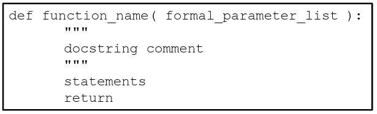

**def** keyword marks the start of the function header.

**function_name** uniquely identifies the function.

**formal_parameter_list**: (optional) values passed to function, required by the function to do its job.

**docstring** comment (optional) describes the function and input/outputs.

Indented statements(1 or more) that make up the function body.

**return** statement (optional) returns calculated values.

```python
def my_function():
  print("Hello from a function")
```

```python
def multiply_numbers( n1, n2 ):
  result = n1 * n2
  return result
```

## Calling Functions

```python
my_function()
```

```
Hello from a function
```

```python
product = multiply_numbers( 10, 20 )
print(product)
```

[output not shown]

## Default Parameter Value

If we call the function without argument, it uses the default value

```python
def my_function(country = "Turkey"):
  print("I am from " + country)

my_function("Sweden")
my_function("India")
my_function()
```

```
I am from Sweden
I am from India
I am from Turkey
```

## Arbitrary Arguments, *args

If you do not know how many arguments that will be passed into your function, add a * before the parameter name in the function definition.

Arbitrary Arguments are often shortened to *args in Python documentations.

```python
def my_courses(*args):
  print("I have " + str(len(args)) + " courses")
  for course in args:
    print(course)

my_courses("Python", "AI", "ML", "Java","dasdas")
```

```
I have 5 courses
Python
AI
ML
Java
dasdas
```

## Arbitrary Keyword Arguments, **kwargs

If you do not know how many keyword arguments that will be passed into your function, add two asterisk: ** before the parameter name in the function definition.

This way the function will receive a dictionary of arguments, and can access the items accordingly:

```python
def my_courses(**kwargs):
  print("I have " + str(len(kwargs)) + " courses")
  for key, value in kwargs.items():
    print(key + ": " + value)

my_courses(course1 = "Python", course2 = "AI", course3 = "ML", course4 = "Java")
```

```
I have 4 courses
course1: Python
course2: AI
course3: ML
course4: Java
```

## pass Statement

**function definitions cannot be empty**, but if you for some reason have a function definition with no content, put in the **pass** statement to avoid getting an error.

```python
def myfunction():
  pass
```

## Variable Scope

The scope of a variable is the part of the program from which the variable can be accessed.

**Local variables** are variables that are defined **within a function**.

Local variables become available from the point that they are defined in a function until the end of the function in which it they are defined.

**Global variables** are that are **defined outside of functions** and have a global scope.

Global variables are visible/accessible from inside functions; however, they cannot be directly updated.

```python
age=45

def my_function2():
  sss = 1 # global
  print("x value inside function: ", sss)

my_function2()
print(sss)
print(age)
```

[output not shown]

**Nonlocal Keyword**

The nonlocal keyword is used to work with variables **inside nested functions**.

The nonlocal keyword makes the variable belong to the outer function.

If you use the nonlocal keyword, the variable will belong to the outer function:

```python
def my_function3():
  name = "Güray"
  def my_function4():
    nonlocal name
    name = "Murat"
  my_function4()
  return name

print(my_function3())
```

```
Murat
```

## Functions as Objects

In Python, **a function can be assigned to a variable**. This assignment does not call the function, instead a reference to that function is created.

```python
# 1. Assigning a function to a variable
def greet(name):
    return "Hello, " + name + "!"

# Assign the function 'greet' to the variable 'my_greeting'
my_greeting = greet

# Now you can call the function through the variable
print(my_greeting("Güray"))
```

```
Hello, Güray!
```

```python
# 2. Passing a function as an argument to another function
#High Order Functions
def apply_function(func, value):
    return func(value)

def square(x):
    return x * x

def exponent(x)
    return x ** x

# Pass the 'square' function to 'apply_function'
result = apply_function(exponent, 5)
print(result)  # Output: 25
```

[output not shown]

```python
# 3. Returning a function from another function
def create_multiplier(factor):
    def multiplier(x):
        return x * factor
    return multiplier

# Create a function that multiplies by 3
multiply_by_3 = create_multiplier(3)

# Create a function that multiplies by 5
multiply_by_5 = create_multiplier(5)

print(multiply_by_3(10))  # Output: 30
print(multiply_by_5(10))  # Output: 50
```

```
30
50
```

```python
# 4. Another example with decorator
def create_operation(operator):
    def operate(x, y):
      if operator == "add":
        return x + y
      elif operator == "subtract":
        return x - y
      elif operator == "multiply":
        return x * y
      elif operator == "divide":
        return x / y
      else:
        return "Invalid Operation"
    return operate

add = create_operation("add")
subtract = create_operation("subtract")

print(add(5, 3)) #Output: 8
print(subtract(5, 3)) #Output: 2
```

```
8
2
```

```python
# 5. Another example with high order function
import math

def do_this(num, func):
    return func(num)

val = float(input('Enter a number: '))

# do this - find the ceiling of the value
result = do_this(val, math.ceil)
print(f'Ceiling of {val} is {result}')

# do this - find the int representation of the value
result = do_this(val, int)
print(f'int representation of {val} is {result}')

# do this - find the square root of the value
result = do_this(val, math.sqrt)
print(f'Rounded square root of {val} is {do_this(result, round)}')
```

```
Enter a number: 5.2
Ceiling of 5.2 is 6
int representation of 5.2 is 5
Rounded square root of 5.2 is 2
```

## Python Lambda

A lambda function is a small **anonymous function**.

A lambda function **can take any number of arguments**, but **can only have one expression**.

`lambda arguments : expression`

```python
#with lambda: add 10 to argument a, and return the result:
x = lambda a : a + 10
print(x(5))

#without lambda:
def add10(a):
  return a + 10

print(add10(5))
```

```
15
15
```

Multiply argument **a** with argument **b** and return the result:

```python
#Multiply argument a with argument b and return the result:
x = lambda a, b : a * b
print(x(5, 6))

#without lambda:
def multiply(a, b):
  return a * b

print(multiply(5, 6))
```

```
30
30
```

**Why Use Lambda Functions?**

The power of lambda is better shown when you **use them as an anonymous function inside another function**.

## Exercises

**Exercise 1**: Trace the following program and find the output:

```python
def f(x):
    def g():
        x = 'abc'
        print('x = ', x)
    def h():
        z = x
        print('z = ', z)
    x = x + 1
    print('x = ', x)
    h()
    g()
    print('x = ', x)
    return g

x = 3
z = f(x)
print('x = ', x)
print('z = ', z)
z()
```

```
x =  4
z =  4
x =  abc
x =  4
x =  3
z =  <function f.<locals>.g at 0x7a3b04d5f420>
x =  abc
```

```python
def sum_digits(number):
    sum_of_digits = 0
    number_str = str(number)  # Convert number to a string

    for digit in number_str:
        sum_of_digits += int(digit)  # Convert digit back to integer and add

    return sum_of_digits

# Get input from the user
while True:
      num = int(input("Enter positive number (or negative number to stop)"))
      if num < 0:
          break  # Exit the loop
      digit_sum = sum_digits(num)
      print("Sum of digits:", digit_sum)
```

```
Enter positive number (or negative number to stop)1258
Sum of digits: 16
Enter positive number (or negative number to stop)-1
```

**Exercise 3: Reverse a Number:** Write a program that flips a number around. For example, if you give it the number 123, it should return 321

```python
def reverse_number(number):
    num_str = str(number) #convert the number to a string
    reversed_str = num_str[::-1] #reverse the string using slicing
    reversed_num = int(reversed_str) #convert back to integer
    return reversed_num

# Get input from the user
num = int(input("Enter a number: "))
reversed_num = reverse_number(num)
print("Reversed number:", reversed_num)
```

```
Enter a number: 123
Reversed number: 321
```

**Exercise 4: Binary to Decimal Conversion:** We're going to work with binary numbers (numbers made up of only 0s and 1s).

**First**, write a program called **is_binary** that checks if a given string is a valid binary number. It should return True if the string contains only 0s and 1s, and False otherwise.

Second, write a program called **convert_to_decimal** that takes a string as input. It should use your is_binary program to check if the string is a valid binary number.

If it's a valid binary number, convert it to its decimal (base-10) equivalent. If it's not a valid binary number, print an error message

```python
def is_binary(binary_string):
    for digit in binary_string:
        if digit != '0' and digit != '1':
            return False
    return True

def convert_to_decimal(binary_string):
    if not is_binary(binary_string):
        return "Invalid binary string"

    decimal_value = 0
    power = 0
    #Iterate through the binary string from right to left
    for digit in reversed(binary_string):
        if digit == '1':
            decimal_value += 2**power
        power += 1

    return decimal_value

# Get input from the user
binary_input = input("Enter a binary number: ")
decimal_output = convert_to_decimal(binary_input)
print(decimal_output)
```

```
Enter a binary number: 1001001
73
```

# Modules

- Python comes with pre-made tools called the **"standard library"**.
- Think of it as a toolbox filled with useful functions and code.
- This toolbox is included with Python.
- The **standard library is organized into "modules"** (smaller toolboxes).
- Each module contains related functions.
- **You can create your own modules**, but it's often unnecessary.
- **Python usually already provides functions for math, text, and common tasks.**

Before using the functions contained in a module, **you must first import the module to your program**.

Importing is done using an **import** statement.

Using the **import** statement, **we can import specific functions within a module or all functions** contained in the module at once.

**Syntax:**

```
from math import sqrt -> makes available only sqrt in math

from math import sqrt, sin, cos -> makes available specific functions listed

from math import * -> makes available all function in math module

import math -> makes available all functions in math module
```

when calling functions, you must add the module name 3

ex: **math.sqrt(25)**

## Create a Module

To create a module just save the code you want in a file with the **file extension .py**:

Save this code in a file named **my_module.py**

```python
def greeting(name):
  print("Hello, " + name)
```

```python
import my_module

my_module.greeting("MIS346")
```

## Naming a Module

```python
import my_module as mm

mm.greeting("MIS346")
```

```python
from my_module import greeting as selamla
selamla("MIS346")
```

## Built-in Modules

There are several **built-in modules in Python**, which you can import whenever you like.

```python
import platform

x = platform.system()
print(x)
```

```
Linux
```

```python
import platform as pl

x = dir(pl)
print(x)
```

[output not shown]

```python
import math
sqrt_val = math.sqrt(64)
pi_const = math.pi
print(sqrt_val)
print(pi_const)
```

```
8.0
3.141592653589793
```

```python
import datetime
date_today = datetime.date.today()
time_now = datetime.datetime.now().time()
print(date_today)
print(time_now)
```

```
2025-03-09
13:31:12.338279
```

[figure not shown]

**Python all built-in modeules**

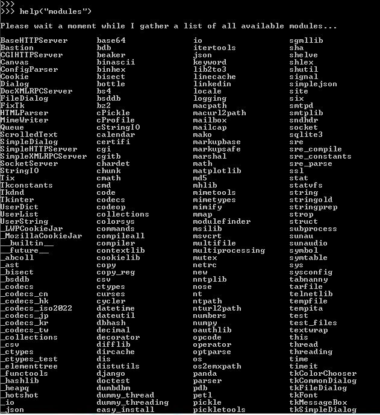

# Files

- Working with files is key for web apps.
- Python lets you **create, read, change, and delete files**.

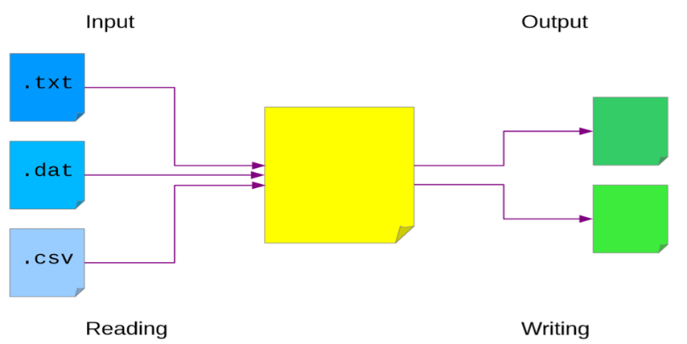

## File Handling

The **open()** function is the main way to work with files.

**open() needs two things**: the **file's name** and what you want to do with it (the **"mode"**).

Here are the different **"modes"**:

**"r"**: **Read** (default). Opens the file to read it. If the file doesn't exist, it gives an error.

**"a": Append**. Opens the file to add to it (at the end). If the file doesn't exist, it creates it.

**"w": Write**. Opens the file to write to it. If the file doesn't exist, it creates it. Warning: This will overwrite the file if it already exists!

**"x": Create**. Creates a new file. If the file already exists, it gives an error.

You can also tell Python if the file is text or binary:

"t": Text (default).

"b": Binary (like for images).

```python
#To open a file for reading it is enough to specify the name of the file:
f = open("demofile.txt")
```

```python
#The code above is the same as:
f = open("demofile.txt", "rt")
#Because "r" for read, and "t" for text are the default values, you do not need to specify them.
```

| Function | Purpose |
| --- | --- |
| `open(fileName, 'w')` | Creates a new file for writing and returns the file object (file handle). |
| `open(fileName, 'r')` | Opens an existing file for reading and returns a file handle. |
| `open(fileName, 'a')` | Opens an existing file for appending and returns a file handle. |
| `fh.read()` | Returns a string containing the contents of the file associated with the file handle. |
| `fh.readline()` | Returns the next line in the file associated with the file handle. |
| `fh.readlines()` | Returns a list, each element of which is one line of the file associated with the file handle. |
| `fh.write(s)` | Writes the string s to the end of the file associated with the file handle. |
| `fh.writeLines(S)` | S is a sequence of strings, writes each element of S as a separate line to the file associated with the file handle. |
| `fh.close()` | Closes the file associated with the file handle. |

## Writing Data to a File

To write to an existing file, you must add a parameter to the open() function:

"w" - Write - will overwrite any existing content

```python
# Open a file named 'MIS346.txt' in write mode ('w').
# This will create the file if it doesn't exist, or overwrite it if it does.
file = open('MIS346.txt', 'w')

# Loop twice (for two names).
for i in range(2):
    # Ask the user to enter a name.
    name = input('Enter name: ')

    # Write the name to the file, followed by a newline character ('\n')
    # to put each name on a separate line.
    file.write(name + '\n')

# Close the file. This is important to save the changes and free up resources.
file.close()
```

```
Enter name: Guray
Enter name: Aylin
```

## Appending Data to a File

To write to an existing file, you must add a parameter to the open() function:

"a" - Append - will append to the end of the file

```python
file=open('MIS346.txt','a')
for i in range(2):
  name=input('Enter name: ')
  file.write(name+'\n')
file.close()
```

```
Enter name: Sabriye
Enter name: Deneme1
```

## Reading Data from File – read()

To open the file, use the built-in open() function.

The open() function returns a file object, which has a **read()** method for reading the content of the file:

```python
file=open('MIS346.txt','r')
file_content=file.read()
print(file_content)
```

```
Guray
Aylin
Sabriye
Deneme
dfsdfsdf
dfgdfgdfg
Sabriye
Deneme1
```

## Read Lines

You can return one line by using the **readline()** method:

```python
file=open('MIS346.txt','r')
print(file.readline())
print(file.readline())
```

```
Guray

Aylin
```

```python
#By looping through the lines of the file, you can read the whole file, line by line:

file=open("MIS346.txt", "r")
for line in file:
  print(line)

#close the file
file.close()
```

```
Guray

Aylin

Sabriye

Deneme

dfsdfsdf

dfgdfgdfg

Sabriye

Deneme1
```

```python
file = open('MIS346.txt', 'r')

# Loop twice (to read two lines).
for i in range(2):
    # Read a single line from the file.
    line = file.readline()

    # Print the line, but remove the last character (which is the newline character '\n').
    # [:-1] is a slicing technique that takes all characters except the last one.
    print(line[:-1])

# Close the file.
file.close()
```

```
Guray
Aylin
```

**Useful String Functions**, you may use with file operations

| Function Name | Purpose |
| --- | --- |
| `s.count(s1)` | Counts how many times the string `s1` occurs in `s`. |
| `s.find(s1)` | Returns the index of the first occurrence of the substring `s1` in `s`, and -1 if `s1` is not in `s`. |
| `s.find(s1, pos)` | Same as `find`, but starts searching from the given `pos`. |
| `s.rfind(s1)` | Same as `find`, but starts from the end of `s` (the ‘r’ in `rfind` stands for reverse). |
| `s.replace(old, new)` | Replaces all occurrences of the string `old` in `s` with the string `new`. |
| `s.strip()` | Removes the leading and trailing whitespace from `s`. |
| `s.rstrip()` | Removes the trailing whitespace from `s`. |

```python
# s.count(s1): Counts how many times the string s1 occurs in s.
s = "hello world hello"
count = s.count("hello")
print(f"s.count('hello'): {count}")  # Output: s.count('hello'): 2
```

```
s.count('hello'): 2
```

```python
# s.find(s1): Returns the index of the first occurrence of the substring s1 in s, and -1 if s1 is not in s.
s = "hello world"

index = s.find("world")
print(f"s.find('world'): {index}")  # Output: s.find('world'): 6

index = s.find("python")
print(f"s.find('python'): {index}") # Output: s.find('python'): -1
```

```
s.find('world'): 6
s.find('python'): -1
```

```python
# s.find(s1, pos): Same as find, but starts searching from the given pos.
s = "hello world hello"
index = s.find("hello", 1)
print(f"s.find('hello', 1): {index}")  # Output: s.find('hello', 1): 12

# s.rfind(s1): Same as find, but starts from the end of s (the ‘r’ in rfind stands for reverse)
s = "hello world hello"
index = s.rfind("hello")
print(f"s.rfind('hello'): {index}")  # Output: s.rfind('hello'): 12
```

```
s.find('hello', 1): 12
s.rfind('hello'): 12
```

```python
# s.replace(old, new): Replaces all occurrences of the string old in s with the string new.
s = "hello world hello"
new_s = s.replace("hello", "goodbye")
print(f"s.replace('hello', 'goodbye'): {new_s}")  # Output: s.replace('hello', 'goodbye'): goodbye world goodbye
```

```
s.replace('hello', 'goodbye'): goodbye world goodbye
```

```python
# s.strip(): Removes the leading and trailing whitespace from s.
s = "   hello world   "
stripped_s = s.strip()
print(f"s.strip(): {stripped_s}")  # Output: s.strip(): hello world

# s.rstrip(): Removes the trailing whitespace from s.
s = "hello world   "
rstrip_s = s.rstrip()
print(f"s.rstrip(): {rstrip_s}")  # Output: s.rstrip(): hello world
```

```
s.strip(): hello world
s.rstrip(): hello world
```

## Exercises

**Exercise 1.** Write a Python program that:

Reads recipes.txt line by line.

Asks the user for an ingredient to remove.

Creates a file cleaned_recipes.txt.

For each recipe, if the ingredient is present, remove it from the recipe string.

Write the cleaned recipe to cleaned_recipes.txt.

If the user inputted ingredient is not present in the recipe then write it to the cleaned_recipes.txt as is.

recipes.txt (Example):

Spaghetti Carbonara : Spaghetti, Eggs, Pancetta, Parmesan Cheese

Chocolate Chip Cookies : Flour, Butter, Sugar, Chocolate Chips

Tomato Soup : Tomatoes, Water, Basil

```python
def clean_recipes():
    try:
        with open("recipes.txt", "r") as infile, open("cleaned_recipes.txt", "w") as outfile:
            ingredient_to_remove = input("Enter the ingredient to remove: ")

            for line in infile:
                if ingredient_to_remove in line:
                    cleaned_line = line.replace(ingredient_to_remove + ",", "")  # Remove with comma
                    cleaned_line = cleaned_line.replace("," + ingredient_to_remove, "")  # remove with comma reversed
                    cleaned_line = cleaned_line.replace(ingredient_to_remove, "")  #remove if no comma
                    outfile.write(cleaned_line)
                else:
                    outfile.write(line)

        print("Recipes cleaned and saved to cleaned_recipes.txt")

    except FileNotFoundError:
        print("Error: recipes.txt not found.")
    except Exception as e:
        print(f"An error occurred: {e}")


clean_recipes()
```

**Exercise 2.** You have a file words.txt with lines like this:

**EnglishWord:AnotherWord**

Write a Python program to:

Read words.txt line by line.

Create a file swapped_words.txt.

words.txt (Example):

Hello:World  
Yes:No  
Up:Down

```python
def swap_words():
    try:
        with open("words.txt", "r") as infile, open("swapped_words.txt", "w") as outfile:
            for line in infile:
                parts = line.strip().split(":")
                if len(parts) == 2:
                    outfile.write(f"{parts[1]}:{parts[0]}\n")
                else:
                    outfile.write(line)  # Keep the line as is if there's no colon

        print("Words swapped and saved to swapped_words.txt")

    except FileNotFoundError:
        print("Error: words.txt not found.")
    except Exception as e:
        print(f"An error occurred: {e}")

swap_words()
```

**Exercise 3: Basic Syllable Check**

You have a file syllables.txt with lines in the format

**Word:SyllableCount**

Write a Python program that:

Reads syllables.txt line by line.

Asks the user to enter a target syllable count.

Creates a file matching_words.txt.

For each line in syllables.txt, if the SyllableCount matches the user's target, write the Word to matching_words.txt.

syllables.txt (Example):

Butterfly:3  
Cat:1  
Beautiful:3  
Dog:1

```python
def check_syllables():
    try:
        with open("syllables.txt", "r") as infile, open("matching_words.txt", "w") as outfile:
            target_syllable_count = input("Enter the target syllable count: ")

            for line in infile:
                word, syllable_count = line.strip().split(":")
                if syllable_count == target_syllable_count:
                    outfile.write(word + "\n")

        print("Matching words saved to matching_words.txt")

    except FileNotFoundError:
        print("Error: syllables.txt not found.")
    except Exception as e:
        print(f"An error occurred: {e}")

check_syllables()
```

# Python Lists

**What are lists for?** Lists are like containers where **you can put lots of things (items) together in one place**. Think of it like a shopping list or a list of your friends' names.

Lists are **one of four main "container" types in Python**. Python has a few different ways to store collections of items: **Lists, Tuples, Sets, and Dictionaries**. They're all a bit different and useful in different situations.

How do you make a list? You **use square brackets []** to create a list.

```python
my_list = ["apple", "banana", "cherry"]
print(my_list)
```

```
['apple', 'banana', 'cherry']
```

List elements can be changed, so a list is **mutable**. Mutable means changeable:

```python
# Change the first item in the list
my_list[0] = "grape"
print(my_list)  # Shows: ['grape', 'banana', 'cherry']
 #(The "apple" was changed to "grape")

# Add a new item to the end of the list
my_list.append("orange")
print(my_list)  # Shows: ['grape', 'banana', 'cherry', 'orange']

# Remove an item from the list
my_list.remove("banana")
print(my_list)  # Shows: ['grape', 'cherry', 'orange']
```

```
['grape', 'banana', 'cherry']
['grape', 'banana', 'cherry', 'orange']
['grape', 'cherry', 'orange']
```

```python
# Creating an empty list to store names
name_list = []

# Creating a list of fruits
fruits = ["apple", "banana", "orange", "kiwi"]

numbers = [2, 8, 3, 6]

# Displaying the list of fruits
print(fruits)  # Output: ['apple', 'banana', 'orange', 'kiwi']

print(numbers)

# Displaying the number of fruits in the list
print(len(fruits))  # Output: 4

# Accessing fruits by their position (index)
print(fruits[0])  # Output: apple (the first fruit)
print(fruits[2])  # Output: orange (the third fruit)

# Trying to access an index that doesn't exist will cause an error
# print(fruits[4])  # This will cause an IndexError

# Using a variable to pick which fruit to access
index = 1
print(fruits[index])  # Output: banana (because index 1 holds "banana")

# Changing "banana" to "grape"
fruits[1] = "grape"
print(fruits)  # Output: ['apple', 'grape', 'orange', 'kiwi']  (The list has been modified!)
```

```
['apple', 'banana', 'orange', 'kiwi']
[2, 8, 3, 6]
4
apple
orange
banana
['apple', 'grape', 'orange', 'kiwi']
```

## Traversing a List

The easiest way to traverse a list in Python is **using a for loop**.

```python
# A list of numbers
numbers = [10, 20, 30, 40, 50]

# Start with a sum of zero
total = 0

# Loop through each number in the list
for number in numbers:
    # Add the current number to the total
    total = total + number

# Print the final sum
print("The sum of the numbers is:", total)
```

```
The sum of the numbers is: 150
```

```python
list= [4, 1, 3, 2]
total=0
for i in range(len(list)):
  total += list[i]
print(total)
```

```
10
```

## What is range() ?

- **range() creates a sequence of numbers**: The range() function is a quick way to generate a series of numbers. For example, range(5) creates a sequence of numbers from 0 to 4.
- **range() is like a read-only list**: You can use range() to do many of the same things you can do with lists or tuples (like accessing elements by index), but you can't change the sequence it creates. It's immutable.
- **range(start, stop, step)**: This is how you control the sequence:

**start**: Where the sequence begins (default is 0).

**stop**: Where the sequence ends (but the sequence doesn't include this number). It stops before this number.

**step**: How much to increment by (default is 1).

You can do things like access elements using their index (e.g., my_range[2]), but you can't join two ranges together or repeat a range like you can with tuples.

```python
# Create a range from 0 to 4
my_range = range(5)
print(list(my_range))  # Output: [0, 1, 2, 3, 4]

# Create a range from 2 to 9
my_range = range(2, 10)
print(list(my_range))  # Output: [2, 3, 4, 5, 6, 7, 8, 9]

# Create a range from 1 to 10, counting by 2
my_range = range(1, 11, 2)
print(list(my_range))  # Output: [1, 3, 5, 7, 9]

# Accessing an element in the range
my_range = range(5)
print(my_range[2])  # Output: 2
```

```
[0, 1, 2, 3, 4]
[2, 3, 4, 5, 6, 7, 8, 9]
[1, 3, 5, 7, 9]
2
```

## List Operations

We can add, change, remove items from list elements

**Append Item to the end of list**

List Modification with the **append()** method

The **append()** method provides a mechanism for extending a list by adding a single element to **its end**.

append() method is a **built-in function** available for list objects in Python.

Its primary function is to add an element to the end of an existing list.

The syntax is straightforward:

`list_name.append(element)`

```python
numbers = [2,1,3]
print(numbers)

numbers.append(5)
print(numbers)
```

```
[2, 1, 3]
[2, 1, 3, 5]
```

**Insert Items**

To insert a list item at a specified index, use the **insert()** method.

The insert() method **inserts an item at the specified index**:

```python
fruits = ["apple", "banana", "cherry"]
print(fruits[1])

#inserts a new item to the specified index
fruits.insert(1, "orange")
print(fruits)

#change item
fruits[0] = "kiwi"
print(fruits)
```

```
banana
['apple', 'orange', 'banana', 'cherry']
['kiwi', 'orange', 'banana', 'cherry']
```

**Extend List**

To append elements **from another list to the current list, use the extend()** method.

*extend() vs. append():*

**append() adds a single element** to the end of a list.

If you append a list to another list, you'll get a list inside a list.

**extend() adds the elements of one list to another**. The result is a single, longer list.

```python
fruits = ["apple", "banana", "cherry"]
tropical_fruits = ["mango", "pineapple", "papaya"]
fruits.extend(tropical_fruits)
print(fruits)
```

```
['apple', 'banana', 'cherry', 'mango', 'pineapple', 'papaya']
```

```python
list1 = [1, 2, 3]
list2 = [4, 5, 6]

# Using extend()
list1.extend(list2)
print(list1)  # Output: [1, 2, 3, 4, 5, 6]

# Reset list1
list1 = [1, 2, 3]

# Using append()
list1.append(list2)
print(list1) # Output: [1, 2, 3, [4, 5, 6]]  (list2 is added as a single element)
```

```
[1, 2, 3, 4, 5, 6]
[1, 2, 3, [4, 5, 6]]
```

**Concatenation**

The concatenation of two lists is a new list that contains the elements of the first list, followed by the elements of the second.

When we concatenate two lists, there are no side effects, meaning that a new list is created, and the original lists being concatenated are not mutated.

```python
myFriends = ['Ali', 'Veli', 'Mehmet']
yourFriends = ['Erdal', 'Volkan']

ourFriends = myFriends + yourFriends
print(ourFriends)
```

```
['Ali', 'Veli', 'Mehmet', 'Erdal', 'Volkan']
```

## List Operations –Finding an Element

We can find the position at which an element occurs.

`list.index(e)`

◦ returns the index of the first occurrence of e in list, gives a run-time error if e is not in list.

```python
friends = ['Güray', 'Aylin', 'Sabriye', 'Aylin', 'Mehmet']
n = friends.index('Aylin')
print(n)  # This will print the index of the first 'Aylin'
n = friends.index('Aylin', n + 1)
print(n)  # This will print the index of the second 'Aylin'
```

```
1
3
```

```python
programming_languages = ["JavaScript","Python","Java","Python","C++","Python"]

print(programming_languages.index("Python"))
```

```
1
```

```python
programming_languages = ["JavaScript","Python","Java","Python","C++","Python"]

python_indices = []

for programming_language in range(len(programming_languages)):
    if programming_languages[programming_language] == "Python":
      python_indices.append(programming_language)

print(python_indices)
```

```
[1, 3, 5]
```

## Python - Loop Lists

You can loop through the list items by using a **for loop**:

```python
list = ["apple", "banana", "cherry"]
for item in list:
  print(item)
```

```
apple
banana
cherry
```

You can go through the items in the list by using their position numbers.

Use the **range()** function along with the **len()** function to create a proper sequence for looping.

```python
list = ["apple", "banana", "cherry"]
for i in range(len(list)):
  print(list[i])
```

```
apple
banana
cherry
```

**Using a While Loop:**

You can go through the items in the list using a while loop.

First, use the **len()** function to find out how many items are in the list. Start at index 0 and continue looping through the items by using their index numbers.

Make sure to **add 1 to the index after each round** of the loop.

```python
list = ["apple", "banana", "cherry"]
i = 0
while i < len(list):
  print(list[i])
  i = i + 1
```

```
apple
banana
cherry
```

**Looping Using List Comprehension**

List Comprehension offers the **shortest syntax for looping** through lists:

```python
list = ["apple", "banana", "cherry"]
[print(x) for x in list]
```

```
apple
banana
cherry
```

```
[None, None, None]
```

## Python - List Comprehension

List comprehension provides a **simpler way to make a new list from an existing list**.

**For example:**

If you have a list of fruits and want to create a new list that includes **only the fruits with the letter "a" in their name**, you can do it easily with list comprehension.

**Without using list comprehension, you would need to write a for loop with an if statement to filter the fruits.**

```python
#long way
fruits = ["apple", "banana", "cherry", "kiwi", "mango"]
newlist = []

for x in fruits:
  if "a" in x:
    newlist.append(x)

print(newlist)
```

```
['apple', 'banana', 'mango']
```

With list comprehension you can do all that **with only one line of code**:

```python
fruits = ["apple", "banana", "cherry", "kiwi", "mango"]

newlist = [x for x in fruits if "a" in x]

print(newlist)
```

```
['apple', 'banana', 'mango']
```

**Syntax:** You can create a new list using this format:

`newlist = [expression for item in iterable if condition == True]`

This will give you a new list without changing the original list.

```python
newlist = [x for x in fruits if x != "apple"]
print(newlist)
```

```
['banana', 'cherry', 'kiwi', 'mango']
```

```python
newlist = [x for x in fruits]
print(newlist)
```

```
['apple', 'banana', 'cherry', 'kiwi', 'mango']
```

```python
#You can use the range() function to create an iterable:
newlist = [x for x in range(10)]
print(newlist)
```

```
[0, 1, 2, 3, 4, 5, 6, 7, 8, 9]
```

The expression can also contain conditions, not like a filter, but as a way to **manipulate the outcome**:

```python
newlist = [x if x != "banana" else "orange" for x in fruits]
#changes banana with orange
print(newlist)
```

```
['apple', 'orange', 'cherry', 'kiwi', 'mango']
```

## Python - Sort Lists

List objects have a **sort() method** that will sort the list alphanumerically, ascending, by default:

```python
list = ["orange", "mango", "kiwi", "pineapple", "banana"]
list.sort()
print(list)
```

```
['banana', 'kiwi', 'mango', 'orange', 'pineapple']
```

```python
list = [100, 80, 65, 84, 33]
list.sort()
print(list)
```

```
[33, 65, 80, 84, 100]
```

**Sort Descending**

To sort descending, use the keyword argument **reverse = True**:

```python
list = [100, 80, 65, 84, 33]
list.sort(reverse=True)
print(list)
```

```
[100, 84, 80, 65, 33]
```

**Customize sorting**

**You can create your own custom function** **for sorting** by using the keyword **key** followed by the **function name**.

This custom function should return a number, which will be used to determine the order of the items in the list (with the lowest number appearing first).

```python
def myfunc(n):
  return abs(n - 50)

list = [100, 50, 65, 82, 23]

list.sort(key = myfunc)

print(list)
```

```
[50, 65, 23, 82, 100]
```

```python
#Perform a case-insensitive sort of the list:

list = ["Banana", "Orange", "Kiwi", "cherry"]
#list.sort()
list.sort(key=str.lower)
print(list)
```

```
['Banana', 'cherry', 'Kiwi', 'Orange']
```

**Reverse Order**:

If you want to change the order of a list to be the opposite of how it is currently arranged, you can use the **reverse() method**.

This method will reverse the order of the elements in the list, **regardless of their alphabetical arrangement**.

```python
list = ["banana", "Orange", "Kiwi", "cherry"]
list.reverse()
print(list)
```

```
['cherry', 'Kiwi', 'Orange', 'banana']
```

## Python - Copy Lists

You can't copy a list just by writing **list2 = list1** because **in this case, list2 will only point to the same list as list1**.

This means that **if you change anything in list1**, those **changes will also appear in list2**.

```python
# Original list
list1 = [1, 2, 3, 4, 5]

# Incorrect way to copy (creates a reference)
list2 = list1

# Both lists will change
list1[0] = 99

print("list1:", list1)  # Output: list1: [99, 2, 3, 4, 5]
print("list2:", list2)  # Output: list2: [99, 2, 3, 4, 5] (also changed)
```

```
list1: [99, 2, 3, 4, 5]
list2: [99, 2, 3, 4, 5]
```

You can use the built-in List **method copy()** to copy a list.

```python
# Correct way to copy a list
list3 = list1.copy()

# Changing list1 won't affect list3
list1[1] = 88

print("list1:", list1)  # Output: list1: [99, 88, 3, 4, 5]
print("list3:", list3)  # Output: list3: [99, 2, 3, 4, 5] (remains unchanged)
```

```
list1: [99, 88, 3, 4, 5]
list3: [99, 2, 3, 4, 5]
```

**Use the list() method**

Another way to create a copy of a list is by using the built-in **list()** method.

This method produces a new list that contains the same elements as the original list, allowing you to modify one without affecting the other.

```python
# Original list
list1 = [1, 2, 3, 4, 5]

# Making a copy using the list() method
list2 = list(list1)

# Changing the original list
list1[0] = 99

print("list1:", list1)  # Output: list1: [99, 2, 3, 4, 5]
print("list2:", list2)  # Output: list2: [1, 2, 3, 4, 5] (remains unchanged)
```

```
list1: [99, 2, 3, 4, 5]
list2: [1, 2, 3, 4, 5]
```

**Use the Slice Operator:**

You can create a copy of a list using the **slice operator (:)**.

This method c**reates a new list containing all the elements from the original list**, without any references.

```python
# Original list
list1 = [1, 2, 3, 4, 5]

# Making a copy using the slice operator
list2 = list1[:]  # This slices the whole list

# Changing the original list
list1[0] = 99

print("list1:", list1)  # Output: list1: [99, 2, 3, 4, 5]
print("list2:", list2)  # Output: list2: [1, 2, 3, 4, 5] (remains unchanged)
```

```
list1: [99, 2, 3, 4, 5]
list2: [1, 2, 3, 4, 5]
```

## List Operations – sum, max, min

In Python, you can use the built-in functions **sum(), max()**, and **min()** to easily find the total, the largest number, and the smallest number in a list of numbers.

```python
numbers = [1, 12, 9, 4]
total = sum(numbers)
print("The sum of the list is:", total)
```

```
The sum of the list is: 26
```

```python
maximum_value = max(numbers)
print("The maximum value in the list is:", maximum_value)
```

```
The maximum value in the list is: 12
```

```python
minimum_value = min(numbers)
print("The minimum value in the list is:", minimum_value)
```

```
The minimum value in the list is: 1
```

## List Operations - Removing

In Python, you can remove elements from a list in **two main ways**: by **index** and by **value**.

**Removing by Index**:

You can use the **pop()** method to remove an item at a specific index.

**If you don't provide an index, it will remove the last item** in the list. However, if the index you provide is not valid, it will cause a runtime error.

```python
my_list = [10, 20, 30, 40, 50]

# Remove the item at index 2
removed_item = my_list.pop(2)
print("Removed item:", removed_item)  # Output: Removed item: 30
print("Updated list:", my_list)
```

```
Removed item: 30
Updated list: [10, 20, 40, 50]
```

```python
# Remove the last item
last_item = my_list.pop()
print("Removed last item:", last_item)  # Output: Removed last item: 50
print("Updated list:", my_list)
```

```
Removed last item: 50
Updated list: [10, 20, 40]
```

```python
friends = ['Harry', 'Emily', 'Bob', 'Jane']

# Remove the friend at index 1 (Emily)
friends.pop(1)
print("Friends after popping index 1:", friends)
```

```
Friends after popping index 1: ['Harry', 'Bob', 'Jane']
```

```python
friends = ['Harry', 'Emily', 'Bob', 'Jane']

# Remove the last friend (Jane)
friends.pop()
print("Friends after popping the last element:", friends)
```

```
Friends after popping the last element: ['Harry', 'Emily', 'Bob']
```

**Removing by Value:**

You can use the **remove()** method to delete the first occurrence of a specific value from the list.

If the value you want to remove does not exist in the list, it will raise a ValueError.

```python
my_list = [10, 20, 30, 20, 40]

# Remove the first occurrence of the value 20
my_list.remove(20)
print("Updated list after removing 20:", my_list)  # Output: Updated list after removing 20: [10, 30, 20, 40]

# Attempting to remove a value that does not exist
try:
    my_list.remove(50)  # This will raise a ValueError
except ValueError:
    print("ValueError: 50 is not in the list.")
```

```
Updated list after removing 20: [10, 30, 20, 40]
ValueError: 50 is not in the list.
```

```python
friends = ['Harry', 'Emily', 'Bob', 'Jane']

# Remove the friend named 'Bob'
friends.remove('Bob')
print("Friends after removing 'Bob':", friends)
```

```
Friends after removing 'Bob': ['Harry', 'Emily', 'Jane']
```

You can remove elements from a list using the **pop()** method by specifying an index or using the **remove()** method to delete an element by its value.

Be careful with invalid indices and non-existent values, as they can lead to runtime errors.

**Using the del Keyword to Remove Elements**

The **del** keyword:

In Python, the **del** keyword can be used to remove an element from a list at a specified index. Additionally, it can be used to delete an entire list.

```python
my_list = ['Apple', 'Banana', 'Cherry', 'Date']

# Remove the item at index 1 (Banana)
del my_list[1]
print("List after deleting index 1:", my_list)
```

```
List after deleting index 1: ['Apple', 'Cherry', 'Date']
```

**Deleting the Entire List**

You can also use the del keyword to delete the entire list. Once you do this, you cannot access the list anymore as it has been removed from memory.

```python
my_list = ['Apple', 'Banana', 'Cherry', 'Date']

# Delete the entire list
del my_list
# print(my_list)  # This would raise a NameError because my_list no longer exists
```

- The del keyword is a powerful way to remove elements from a list by specifying the index.
- **It can also delete the entire list**, making it unavailable for future use.
- Using del allows for precise control over the contents of a list, but be cautious with its use, especially when deleting the whole list.

## Splitting Strings as Lists

In Python, you can use the **split()** method to divide a string into a list of substrings based on a specified delimiter.

**Splitting with a Specified Delimiter:**

You can specify a character or string as a delimiter when using split(). The **method will separate the string wherever this delimiter occurs**.

```python
s = 'dog,cat,mouse,horse'

# Split the string using ',' as the delimiter
words = s.split(',')
print("Words after splitting by comma:", words)
# Output: Words after splitting by comma: ['dog', 'cat', 'mouse', 'horse']
```

```
Words after splitting by comma: ['dog', 'cat', 'mouse', 'horse']
```

**Splitting with Whitespace:**

If you omit the delimiter, the split() method will use any whitespace character (spaces, tabs, newlines) as the default delimiter, and it will remove any extra whitespace.

```python
words2 = 'dog cat mouse horse'.split()
print("Words after splitting by whitespace:", words2)
```

```
Words after splitting by whitespace: ['dog', 'cat', 'mouse', 'horse']
```

- The split(d) method splits a string s into a list of substrings using the specified delimiter d.
- If no delimiter is provided, the method separates the string using any whitespace characters and discards any extra spaces.
- This method is useful for breaking down strings into manageable pieces for processing or analysis.

## Python Built-in List Methods

| Method | Description |
| --- | --- |
| append() | Adds an element at the end of the list. |
| clear() | Removes all the elements from the list. |
| copy() | Returns a shallow copy of the list. |
| count() | Returns the number of elements with the specified value. |
| extend() | Adds the elements of a list (or any iterable) to the end of the current list. |
| index() | Returns the index of the first element with the specified value. |
| insert() | Adds an element at the specified position in the list. |
| pop() | Removes the element at the specified position and returns it. |
| remove() | Removes the first item with the specified value. |
| reverse() | Reverses the order of the elements in the list. |
| sort() | Sorts the elements of the list in ascending order. |

# Python Tuples ()

**Tuples** are a type of data structure in Python that store an ordered sequence of elements. They can contain different types of values, such as integers, strings, and more.

**Key Features of Tuples**

- **Ordered**: The elements in a tuple maintain their order.
- **Immutable/unchangeable**: Once a tuple is created, **you cannot change its elements**. This means **you cannot add, remove, or modify elements** after the tuple is created.
- **Syntax**: Tuples are represented using parentheses ().

**Tuples are generally faster than lists** when it comes to iteration or access because of their fixed size and immutability. **They consume slightly less memory** compared to lists, making them a better choice for storing data that doesn't need to be modified.

## Creating tuples

```python
#Creating an Empty Tuple:
t1 = ()
print(t1)
print(type(t1))
```

```
()
<class 'tuple'>
```

**Creating a Tuple with One Item:**

In Python, to create a **tuple that contains only one item, you must include a trailing comma after the item**. Without the comma, Python will not recognize it as a tuple but will treat it as the item itself.

```python
# Creating a tuple with one item (remember the comma)
thistuple = ("apple",)
print(type(thistuple))  # Output: <class 'tuple'>

# This is NOT a tuple
thistuple = ("apple")
print(type(thistuple))  # Output: <class 'str'>
```

```
<class 'tuple'>
<class 'str'>
```

**Creating Tuples with multi values:**

```python
tuple1 = ("apple", "banana", "cherry")
tuple2 = (1, 5, 7, 9, 3)
tuple3 = (True, False, False)
```

**Creating a Tuple with Mixed Values:**

```python
t2 = (1, "Two", 3)
print(t2)
```

```
(1, 'Two', 3)
```

**Accessing an Element in a Tuple:**

You can access elements using their index (starting from 0).

```python
print(t2[1])
```

```
Two
```

**Attempting to Change an Element:**

Since tuples are immutable, trying to change an element will result in an error.

```python
t2[0] = 5
```

```
---------------------------------------------------------------------------
TypeError                                 Traceback (most recent call last)
<ipython-input-24-707d2748f024> in <cell line: 0>()
----> 1 t2[0] = 5

TypeError: 'tuple' object does not support item assignment
```

## Unpacking a Tuple

When we create a tuple, we typically assign values to it, which is known as **"packing"**.

In Python, **we can also extract those values back into variables**. This process is called **"unpacking"**.

```python
#Packing/Creating a Tuple
fruits = ("apple", "banana", "cherry")
print(fruits[1])
print(fruits)
```

```
banana
('apple', 'banana', 'cherry')
```

```python
#Unpacking a Tuple
(green, yellow, red) = fruits

print(green)  # Output: apple
print(yellow) # Output: banana
print(red)    # Output: cherry
```

```
apple
banana
cherry
```

**IMPORTANT NOTE**:

The **number of variables must match the number of values in the tuple**. If they don't, you can use an asterisk **(*)** to collect the remaining values into a list.

```python
#Using Asterisk *
# Assign the rest of the values as a list called "red"
fruits = ("apple", "banana", "cherry", "strawberry", "raspberry")

(green, yellow, *red) = fruits

print(green)   # Output: apple
print(yellow)  # Output: banana
print(red)     # Output: ['cherry', 'strawberry', 'raspberry']
```

```
apple
banana
['cherry', 'strawberry', 'raspberry']
```

**Asterisk in Different Positions:**

If you place the **asterisk in a different position (not at the end)**, Python will assign values to that variable until the number of remaining values matches the number of variables left.

```python
# Add a list of values to the "tropic" variable
fruits = ("apple", "mango", "papaya", "pineapple", "cherry")

(green, *tropic, red) = fruits

print(green)   # Output: apple
print(tropic)  # Output: ['mango', 'papaya', 'pineapple']
print(red)     # Output: cherry
```

```
apple
['mango', 'papaya', 'pineapple']
cherry
```

**Packing:** Assign values to create a tuple.

**Unpacking:** Extract values from a tuple into variables. Use an asterisk (*) to gather extra values into a list if there are more values than variables.

**Placing the asterisk in different positions** allows for flexible unpacking depending on how you want to group the values.

**Tuple Methods:**

## Python Built-in Tuple Methods

| Method | Description |
| --- | --- |
| count() | Returns the number of times a specified value occurs in a tuple. |
| index() | Searches the tuple for a specified value and returns the position of where it was found. |

# Python Sets {}

**Sets** are a built-in data type in Python used to store multiple items in a single variable. They are one of the four main data types for storing collections of data, alongside lists, tuples, and dictionaries. Each of these data types has its own unique qualities and uses.

**Key Characteristics of Sets**

**Unordered:**

Sets do not maintain any specific order for their items. This means that the **items can appear in a different order each time you access the set**. **You cannot refer to set items by index or key**.

**Unchangeable:**

While you cannot change the items in a set once it is created (i.e., you cannot modify existing items), **you can add new items or remove existing ones.**

**No Duplicate Values:**

**Sets do not allow duplicate values.** If you try to add a duplicate item, it will be ignored.

**Syntax**

Sets are created using curly brackets **{}**.

## Creating a Set

```python
my_set = {"apple", "banana", "cherry"}
print(my_set)
```

```
{'banana', 'cherry', 'apple'}
```

```python
my_set_number={10, 40, 50,70}
print(my_set_number)
```

```
{40, 10, 50, 70}
```

Since sets are unordered, the **items may appear in a different order each time** you print or access the set. Python calculates order according its efficiency.

Also, **you cannot access items by index.**

```python
print(my_set[0])
```

```
---------------------------------------------------------------------------
TypeError                                 Traceback (most recent call last)
<ipython-input-42-502d757570ee> in <cell line: 0>()
----> 1 print(my_set[0])

TypeError: 'set' object is not subscriptable
```

```python
set1 = {"apple", "banana", "cherry"}
set2 = {1, 5, 7, 9, 3}
set3 = {True, False, False}
```

You can **store different data types**. It is also possible.

```python
set4={10,"Hello",20, True, 12.5}
print( set4)
```

```
{True, 20, 'Hello', 10, 12.5}
```

- **You cannot change the items in a set after it has been created**. However, you can remove items and add new items.

```python
my_set = {"apple", "banana", "cherry"}
# thisset[0] = "orange"  # This will raise a TypeError
```

You can add new items or remove existing ones. Use **remove()** and **add()** methods.

## Removing Items from a Set

In Python, you can remove items from a set using several methods: **remove()**, **discard()**, **pop()**, and **clear()**. Each method has its own characteristics and uses.

**Using the remove() Method:**

The remove() method removes a specified item from the set. If the item to be removed does not exist, it raises a KeyError.

```python
my_set = {"apple", "banana", "cherry"}

# Remove "banana" using the remove() method
my_set.remove("banana")

print(my_set)
```

```
{'cherry', 'apple'}
```

**Using the discard() Method:**

The **discard()** method also removes a specified item but does not raise an error if the item does not exist.

```python
my_set = {"apple", "banana", "cherry"}

# Remove "banana" using the discard() method
my_set.discard("banana")

print(my_set)
```

```
{'cherry', 'apple'}
```

**Using the pop() Method:**

The **pop()** method removes a random item from the set and returns it. Since sets are unordered, you cannot predict which item will be removed.

```python
my_set = {"apple", "banana", "cherry"}

x = my_set.pop()  # Removes and returns a random item
print(x)           # Output: Could be 'apple', 'banana', or 'cherry'
print(my_set)
```

```
banana
{'cherry', 'apple'}
```

**Using the clear() Method:**

The **clear()** method removes all items from the set, resulting in an empty set.

```python
my_set = {"apple", "banana", "cherry"}

my_set.clear()  # Empties the set
print(my_set)
```

```
set()
```

**Using the del Keyword:**

The **del** keyword can be used to delete the entire set. **After using del, the set no longer exists.**

```python
my_set = {"apple", "banana", "cherry"}

del my_set
print(my_set)
```

```
---------------------------------------------------------------------------
NameError                                 Traceback (most recent call last)
<ipython-input-52-af5441e03b96> in <cell line: 0>()
      2
      3 del my_set
----> 4 print(my_set)

NameError: name 'my_set' is not defined
```

**remove():** Removes a specified item. Raises an error if the item does not exist.

**discard():** Removes a specified item. Does not raise an error if the item does not exist.

**pop():** Removes and returns a random item. Unordered, so you cannot predict which item is removed.

**clear():** Empties the set, leaving it as an empty set.

**del:** Deletes the entire set.

## Adding Items to Sets

Once a set is created, **you cannot change its existing items**, **but you can add new items**. There are several methods to add items to a set:

**add(), update()**, and more.

**Using the add() Method:**

To add a single item to a set, use the **add()** method.

```python
# Create a set of fruits
fruit_set = {"grape", "kiwi", "watermelon"}

# Add an item to the set using the add() method
fruit_set.add("orange")

print(fruit_set)
```

```
{'grape', 'watermelon', 'kiwi', 'orange'}
```

**Using the update() Method:**

To add items from another set into the current set, use the **update()** method.

```python
# Create a set of fruits
fruit_set = {"grape", "kiwi", "watermelon"}
tropical_set = {"pineapple", "mango", "papaya"}

# Add elements from tropical_set into fruit_set
fruit_set.update(tropical_set)

print(fruit_set)
```

```
{'kiwi', 'papaya', 'pineapple', 'grape', 'watermelon', 'mango'}
```

**Adding Any Iterable:**

The object passed to the **update()** method does not have to be a set; it can be any iterable object, such as tuples, lists, or dictionaries.

```python
# Create a set of fruits
fruit_set = {"grape", "kiwi", "watermelon"}
my_fruit_list = ["banana", "orange"]

# Add elements of my_fruit_list to fruit_set
fruit_set.update(my_fruit_list)

print(fruit_set)  # Output: {'grape', 'kiwi', 'banana', 'orange', 'watermelon'} (order may vary)
```

```
{'grape', 'watermelon', 'orange', 'banana', 'kiwi'}
```

- Use the **add() method to add a single item** to a set.
- Use the **update() method to add multiple items** from another set or any iterable (like lists or tuples) to the current set.

```python
#Loop through the set, and print the values:

my_set = {"apple", "banana", "cherry"}
print(my_set)

for x in my_set:
  print(x)
```

```
{'banana', 'cherry', 'apple'}
banana
cherry
apple
```

## Python - Join Sets

There are several methods to join two or more sets in Python. Each method serves a different purpose, allowing for various types of set operations.

**Union:**

The **union() method returns a new set containing all items from both sets.**

```python
# Create two sets
setA = {"x", "y", "z"}
setB = {10, 20, 30}

# Use union() method
setC = setA.union(setB)
print(setC)  # Output: order may change {10, 20, 30, 'x', 'y', 'z'}
```

```
{'x', 20, 'y', 'z', 10, 30}
```

You can also use the **| operator** to achieve the same result.

```python
# Create two sets
setA = {"x", "y", "z"}
setB = {10, 20, 30}

# Use | operator
setC = setA | setB
print(setC)  # Output: {10, 20, 30, 'x', 'y', 'z'}
```

```
{'x', 20, 'y', 'z', 10, 30}
```

Joining Multiple Sets:

You can join multiple sets using both the union() method and the | operator.

```python
setA = {"x", "y"}
setB = {10, 20}
setC = {"A", "B"}
setD = {"apple", "banana"}

combined_set = setA.union(setB, setC, setD)
print(combined_set)  # Output may vary
```

```
{'banana', 'x', 20, 'y', 10, 'A', 'B', 'apple'}
```

**Joining a Set and a Tuple**

The **union()** method allows you to join a set with other data types, like tuples or lists, while the **| operator cannot.**

```python
setX = {"x", "y", "z"}
tupleY = (1, 2, 3)

setZ = setX.union(tupleY)
print(setZ)  # Output: {1, 2, 3, 'x', 'y', 'z'}
```

```
{'x', 2, 1, 3, 'y', 'z'}
```

**Intersection**

The **intersection()** method returns a new set containing only the items that are **"present in both sets"**.

**Example:** Join two sets, keeping only duplicates.

```python
setX = {"apple", "banana", "kiwi"}
setY = {"banana", "orange", "apple"}

setZ = setX.intersection(setY)
print(setZ)
```

```
{'banana', 'apple'}
```

You can use the **& operator instead of the intersection()** method.

```python
setZ = setX & setY
print(setZ)
```

```
{'banana', 'apple'}
```

The **intersection_update()** method keeps only the duplicates and modifies the original set.

```python
setX.intersection_update(setY)
print(setX)
```

```
{'banana', 'apple'}
```

**Difference:**

The **difference()** method returns a new set **with items from the first set that are not in the second set**.

Example: Keep all items from setX that are not in setY.

```python
setX = {"apple", "banana", "kiwi"}
setY = {"banana", "orange", "apple"}

setZ = setX.difference(setY)
print(setZ)
```

```
{'kiwi'}
```

You can use the **- operator** instead of the **difference()** method.

```python
setZ = setX - setY
print(setZ)  # Output: {'kiwi'}
```

```
{'kiwi'}
```

The **difference_update()** method changes the original set to keep only items that are not in the second set.

**Example:** Update setX to keep items that are not in setY.

```python
setX.difference_update(setY)
print(setX)  # Output: {'kiwi'}
```

```
{'kiwi'}
```

**Symmetric Differences:**

The **symmetric_difference()** method returns a new set **with items that are not present in both sets**.

**Example:** Keep items not present in both sets.

```python
setX = {"apple", "banana", "kiwi"}
setY = {"banana", "orange", "apple"}

setZ = setX.symmetric_difference(setY)
print(setZ)  # Output: {'orange', 'kiwi'}
```

```
{'kiwi', 'orange'}
```

You can use the **^ operator** as well.

```python
setZ = setX ^ setY
print(setZ)  # Output: {'orange', 'kiwi'}
```

```
{'kiwi', 'orange'}
```

The **symmetric_difference_update()** method modifies the original set.

```python
setX.symmetric_difference_update(setY)
print(setX)  # Output: {'orange', 'kiwi'}
```

```
{'kiwi', 'orange'}
```

- Various methods allow you to join sets and perform different set operations.
- **Union** combines sets with union() or |.
- **Update** modifies the original set.
- **Intersection** keeps duplicates with intersection() or &.
- **Difference** keeps unique items from one set with difference() or -.
- **Symmetric Difference** keeps items that are unique to each set with symmetric_difference() or ^.

## Python Built-in Set Methods

| Method | Shortcut | Description |
| --- | --- | --- |
| add() |  | Adds an element to the set. |
| clear() |  | Removes all the elements from the set. |
| copy() |  | Returns a shallow copy of the set. |
| difference() | - | Returns a set containing the difference between two or more sets. |
| difference_update() | -= | Removes the items in this set that are also included in another, specified set. |
| discard() |  | Removes the specified item from the set; does not raise an error if the item does not exist. |
| intersection() | & | Returns a set that contains the intersection of two other sets. |
| intersection_update() | &= | Removes the items in this set that are not present in other specified set(s). |
| isdisjoint() |  | Returns whether two sets have no items in common. |
| issubset() | <= | Returns whether another set contains this set. |
|  | < | Returns whether all items in this set are present in other specified set(s). |
| issuperset() | >= | Returns whether this set contains another set. |
|  | > | Returns whether all items in other specified set(s) are present in this set. |
| pop() |  | Removes and returns an arbitrary element from the set; raises an error if the set is empty. |
| remove() |  | Removes the specified element from the set; raises an error if the element does not exist. |
| symmetric_difference() | ^ | Returns a set with the symmetric differences of two sets. |
| symmetric_difference_update() | ^= | Inserts the symmetric differences from this set and another specified set. |
| union() | \| | Returns a set containing the union of two or more sets. |
| update() | \|= | Updates the set with the union of this set and others. |

# Python Dictionaries {"key":value}

**What is a Dictionary?**

Dictionaries are used to store data in the format of **key-value pairs**.

A dictionary is a collection that is **ordered, changeable, and does not allow duplicates.**

Starting **from Python version 3.7, dictionaries maintain the order of items**. In Python 3.6 and earlier versions, dictionaries did not have a defined order.

Dictionaries are created using curly brackets **{}** and include **keys** and their corresponding **values**.

A dictionary is a container in Python that stores pairs of keys and values. It is often referred to as a map because it maps unique keys to their corresponding values.

Each key in a dictionary must be unique—meaning you cannot have two identical keys. However, multiple keys can point to the same value. This allows for flexibility in how you store and access your data.

**Key Characteristics:**

- **Unique Keys:** Each key in a dictionary can only appear once.
- **Duplicated Values:** While values can be the same, each value must be paired with a unique key.

## Creating a dictionary

`my_dict = {key1: value1, key2: value2, ..., keyN: valueN}`

You can create an empty dictionary, using empty braces.

**dict = {}**

```python
my_car = {
  "make": "TOGG",
  "model": "Model T10X",
  "year": 2024
}
print(my_car)
print(type(my_car))
```

```
{'make': 'TOGG', 'model': 'Model T10X', 'year': 2024}
<class 'dict'>
```

```python
fruit_colors = {
    "apple": "red",
    "banana": "yellow",
    "grape": "purple",
    "orange": "orange",
    "pear": "green"
}
print(fruit_colors)

print(fruit_colors["banana"])
```

```
{'apple': 'red', 'banana': 'yellow', 'grape': 'purple', 'orange': 'orange', 'pear': 'green'}
yellow
```

```python
# Create a dictionary to store phone numbers
phone_book = {
    'Güray': 1234567,
    'Aylin': 3214566,
    'Sabriye': 2124568
}
print(phone_book)
```

```
{'Güray': 1234567, 'Aylin': 3214566, 'Sabriye': 2124568}
```

## Dictionary Items - Data Types

The values in dictionary items can be of any data type:

```python
teacher_profile = {
    "name": "Güray ARIK",          # String
    "age": 45,                        # Integer
    "enrolled": True,                 # Boolean
    "courses": ["Python", "Java", "AI"]  # List
}
```

## Python - Dictionary Access Items

You can access the values in the dictionary using their corresponding keys.

**For example:**

```python
print(teacher_profile["name"])
print(teacher_profile["age"])
print(teacher_profile["enrolled"])
print(teacher_profile["courses"])
```

```
Güray ARIK
45
True
['Python', 'Java', 'AI']
```

If you want to **access an item from the list of courses**, you can do this:

```python
print(teacher_profile["courses"][1])
```

```
Java
```

There is also a method called **get()**that will give you the same result:

```python
print(teacher_profile.get('name'))
```

```
Güray ARIK
```

## Getting Keys, Values, and Items from a Dictionary

**Get Keys:**

The **keys()** method returns a view object containing all the keys in the dictionary.

**Example:** Retrieve the keys from a dictionary:

```python
vehicle = {
    "make": "Toyota",
    "model": "Camry",
    "year": 2020
}

keys_list = vehicle.keys()

print(keys_list) # Before any changes
```

```
dict_keys(['make', 'model', 'year'])
```

The keys list is a view of the dictionary, which means that any changes made to the dictionary will also be reflected in the keys list.

Updating the Dictionary:

```python
# Add a new item to the dictionary
vehicle["color"] = "blue"

print(keys_list)  # After adding a new key
```

```
dict_keys(['make', 'model', 'year', 'color'])
```

**Get Values:**

The values() method returns a view object containing all the values in the dictionary.

**Example:** Retrieve the values from a dictionary:

```python
values_list = vehicle.values()

print(values_list)  # Before any changes
```

```
dict_values(['Toyota', 'Camry', 2020, 'blue'])
```

## Updating the Dictionary:

```python
# Change the year value
vehicle["year"] = 2021

print(values_list)  # After the change
```

```
dict_values(['Toyota', 'Camry', 2021, 'blue'])
```

## Add a New Item:

```python
# Add another key-value pair
vehicle["owner"] = "Güray"

print(values_list)  # After adding a new item
```

```
dict_values(['Toyota', 'Camry', 2021, 'blue', 'Güray'])
```

## Get Items

The **items()** method returns a view object of all the key-value pairs in the dictionary as tuples in a list.

Example: Retrieve items from a dictionary:

```python
items_list = vehicle.items()

print(items_list)
```

```
dict_items([('make', 'Toyota'), ('model', 'Camry'), ('year', 2021), ('color', 'blue'), ('owner', 'Güray')])
```

## Check if a Key Exists

To check if a specific key is in a dictionary, you can use the `in` keyword.

```python
if "make" in vehicle:
    print("Yes, 'make' is one of the keys in the vehicle dictionary.")

if "color" in vehicle:
    print("Yes, 'color' is one of the keys in the vehicle dictionary.")
else:
    print("No, 'color' is not one of the keys in the vehicle dictionary.")
```

```
Yes, 'make' is one of the keys in the vehicle dictionary.
Yes, 'color' is one of the keys in the vehicle dictionary.
```

```python
# Phone directory dictionary
phone_directory = {
    'Güray': 4324234,
    'Aylin': 4565677,
    'Sabriye': 7897892
}

# Continuous search loop
def contact_search():
    while True:
        # Prompt for name
        name = input('Enter a name to search (or "quit" to exit): ').strip().capitalize()

        # Exit condition
        if name == 'Quit':
            print("Exiting contact search.")
            break

        # Search in directory
        if name in phone_directory:
            print(f"{name}'s contact number is: {phone_directory[name]}")
        else:
            print(f"{name} is not in the contact directory.")

# Run the search function
contact_search()
```

```
Enter a name to search (or "quit" to exit): Güray
Güray's contact number is: 4324234
Enter a name to search (or "quit" to exit): quit
Exiting contact search.
```

```python
# Phone directory dictionary
phone_directory = {
    'Güray': 4324234,
    'Aylin': 4565677,
    'Sabriye': 7897892
}

def update_contact():
    # Prompt for name and number
    name = input('Enter person to update: ').strip().capitalize()
    number = input('Enter phone number: ').strip()

    try:
        # Convert number to integer for validation
        number = int(number)

        # Check if contact exists
        if name in phone_directory:
            # Update existing contact
            phone_directory[name] = number
            print(f"{name} updated! ({number})")
        else:
            # Add new contact
            phone_directory[name] = number
            print(f"{name} added! ({number})")

    except ValueError:
        # Handle invalid number input
        print("Invalid phone number. Please enter digits only.")

# Function to display current directory
def show_directory():
    print("\nCurrent Phone Directory:")
    for contact, phone_number in phone_directory.items():
        print(f"{contact}: {phone_number}")

# Main interaction loop
def contact_management():
    while True:
        show_directory()
        update_contact()

        # Ask if user wants to continue
        continue_update = input("Update another contact? (yes/no): ").lower()
        if continue_update != 'yes':
            break

    print("\nFinal Phone Directory:")
    show_directory()

# Run the contact management program
contact_management()
```

```
Current Phone Directory:
Güray: 4324234
Aylin: 4565677
Sabriye: 7897892
Enter person to update: Güray
Enter phone number: 1111111
Güray updated! (1111111)
Update another contact? (yes/no): no

Final Phone Directory:

Current Phone Directory:
Güray: 1111111
Aylin: 4565677
Sabriye: 7897892
```

```python
# Initial phone directory
phone_directory = {
    'Güray': 4324234,
    'Aylin': 4565677,
    'Sabriye': 7897892
}

def remove_contact():
    # Get contact name to remove
    name = input('Enter person to remove: ').capitalize()

    # Check and remove contact
    if name in phone:
        del phone[name]
        print(f'{name} removed!')
    else:
        print(f'{name} not in phone book')

# Run removal process
while True:
    # Show current directory
    print("\nCurrent Directory:")
    for contact, number in phone.items():
        print(f"{contact}: {number}")

    # Remove contact
    remove_contact()

    # Continue option
    choice = input("Remove another? (yes/no): ").lower()
    if choice != 'yes':
        break

# Final directory display
print("\nFinal Directory:")
for contact, number in phone.items():
    print(f"{contact}: {number}")
```

- Use **keys()** to get a view of all keys.
- Use **values()** to get a view of all values.
- Use **items()** to get a view of all key-value pairs.
- Use the **in** keyword to check for the presence of a key in the dictionary.

## Python - Remove Dictionary Items

In Python, there are several methods to remove items from a dictionary.

**Using the pop() Method**

The pop() method removes the item corresponding to the specified key.

```python
fruit_count = {
    "apples": 10,
    "bananas": 15,
    "oranges": 20
}

fruit_count.pop("bananas")
print(fruit_count)  # Output: {'apples': 10, 'oranges': 20}
```

```
{'apples': 10, 'oranges': 20}
```

**Using the popitem() Method**

The **popitem() method removes the last inserted item** from the dictionary. In versions of Python before 3.7, it would remove a random item.

```python
fruit_count = {
    "apples": 10,
    "bananas": 15,
    "oranges": 20
}

fruit_count.popitem()
print(fruit_count)  # Output may vary, but will remove 'oranges' based on the last inserted item
```

```
{'apples': 10, 'bananas': 15}
```

**Using the del Keyword**

The del keyword can remove an item with a specific key.

```python
fruit_count = {
    "apples": 10,
    "bananas": 15,
    "oranges": 20
}

del fruit_count["oranges"]
print(fruit_count)  # Output: {'apples': 10, 'bananas': 15}
```

```
{'apples': 10, 'bananas': 15}
```

You can also use the **del keyword to delete the entire dictionary:**

```python
fruit_count = {
    "apples": 10,
    "bananas": 15,
    "oranges": 20
}

del fruit_count
# print(fruit_inventory)  # This will cause an error because 'fruit_inventory' no longer exists.
```

**Using the clear() Method**

The **clear()** method **removes all items** from the dictionary, leaving it empty.

```python
fruit_count = {
    "apples": 10,
    "bananas": 15,
    "oranges": 20
}

fruit_count.clear()
print(fruit_count)  # Output: {}
```

```
{}
```

- Use **pop()** to remove an item by its key.
- Use **popitem()** to remove the last inserted item.
- Use the **del** keyword to delete an item or the entire dictionary.
- Use **clear()** to empty the dictionary completely.

## Loop Through a Dictionary

You can easily loop through a dictionary in Python using a **for loop**. When looping, **you have options to access keys, values, or both**.

**Looping Through Keys**

When you iterate over a dictionary directly, you get the keys.

```python
book_collection = {
    "title": "1984",
    "author": "George Orwell",
    "year": 1949
}

# Print all key names in the dictionary, one by one
for key in book_collection:
    print(key)  # Output: title, author, year
```

```
title
author
year
```

**Looping Through Values**

You can also use the keys to access the values of the dictionary.

```python
# Print all values in the dictionary, one by one
for key in book_collection:
    print(book_collection[key])
```

```
1984
George Orwell
1949
```

**Looping Through Both Keys and Values**

If you want to loop through both the keys and values, you can use the **items() method**, which returns a view object containing **key-value pairs** as tuples:

```python
book_collection = {
    "title": "1984",
    "author": "George Orwell",
    "year": 1949
}

for key, value in book_collection.items():
    print(f"{key}: {value}")
```

```
title: 1984
author: George Orwell
year: 1949
```

- Looping through a dictionary by itself will give you the keys.
- Use **values()** to loop through the values.
- Use **items()** to loop through both the keys and values.

## Copy a Dictionary

When you try to copy a dictionary using simple assignment, **you don't actually create a new dictionary**.

Instead, **you create a reference that points** to the same dictionary.

This means any changes made to the original dictionary will automatically appear in the "copied" dictionary.

```python
# This creates a reference, not a true copy
student_records = {
    "name": "Aylin",
    "grade": 80,
    "subjects": ["Math", "Science"]
}

# Incorrect way to copy
duplicate_records = student_records

# Changing the original affects the "copy"
student_records["grade"] = 12
print(duplicate_records)  # The grade changes in both dictionaries
```

```
{'name': 'Aylin', 'grade': 12, 'subjects': ['Math', 'Science']}
```

**Using the copy() Method**

```python
student_records = {
    "name": "Aylin",
    "grade": 80,
    "subjects": ["Math", "Science"]
}

# Create a true copy using copy() method
safe_records = student_records.copy()

# Changes to original do not affect the copy
student_records["grade"] = 90

print(student_records)
print(safe_records)
```

```
{'name': 'Aylin', 'grade': 90, 'subjects': ['Math', 'Science']}
{'name': 'Aylin', 'grade': 80, 'subjects': ['Math', 'Science']}
```

**Using the dict() Function**

```python
student_records = {
    "name": "Aylin",
    "grade": 80,
    "subjects": ["Math", "Science"]
}

# Create a copy using dict() function
backup_records = dict(student_records)

# Changes to original do not affect the copy
student_records["grade"] = 100

print(student_records)
print(backup_records)
```

```
{'name': 'Aylin', 'grade': 100, 'subjects': ['Math', 'Science']}
{'name': 'Aylin', 'grade': 80, 'subjects': ['Math', 'Science']}
```

| Function | Purpose | Example |
| --- | --- | --- |
| `len(d)` | Returns number of items in dictionary | contacts = {'Ana': 6413354, 'Enes': 6543210} len(contacts) # Output: 2 |
| `d.keys()` | Returns view of all keys | contacts.keys() # Output: dict_keys(['Ana', 'Enes']) |
| `d.values()` | Returns view of all values | contacts.values() # Output: dict_values([6413354, 6543210]) |
| `k in d` | Checks if key exists | `'Ana' in contacts # Output: True` |
| `d[k]` | Retrieves value for key | `contacts['Ana'] # Output: 6413354` |
| `d.get(k, v)` | Returns value for key or default | contacts.get('Maria', 'Not Found') # Output: Not Found |
| `d[k] = v` | Add/update key-value pair | contacts['Maria'] = 9876543 # Adds new contact |
| `d.pop(k)` | Removes and returns key-value pair | removed = contacts.pop('Ana') # Removes Ana's contact |

## Understanding Lists and Dictionaries in Memory

**Mutable vs. Immutable**

**Mutable:**

These can be changed after you create them. Think of them like a flexible container where you can add or remove items. Examples include Lists and Dictionaries.

**Immutable:**

These cannot be changed once they’re made. They are like a sealed container. Examples include Numbers and Strings. How Memory Works

When you create a list or dictionary, it is stored in memory. The name you give to it is like a sticky note that points to that memory location. If you change the contents of the list or dictionary, all sticky notes (or variable names) that point to that same memory location will also show the change.

# Python Classes and Objects

Python is a programming language that follows the **object-oriented paradigm**.

In Python, nearly everything is treated as an object, complete with its own properties and methods.

A **class serves as a blueprint for creating objects**, similar to a constructor.

## Creating a Class

A class is essentially a blueprint that outlines the structure (data and behaviors) of a group of objects. For instance, the `str` class specifies how all string objects operate.

Within a class, **methods** are defined to establish the **behaviors** of the object, while **variables** (attributes) are utilized to **determine the state of the object**.

Once a class is defined, we can create multiple instances of that class, enabling us to access and utilize their features effectively.

To define a class, use the keyword `class`:

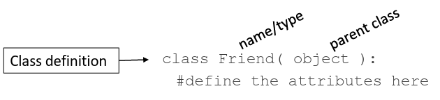

```python
class Friend(object):
    name = "Güray"
```

The word **object means** that the class is a Python object and inherits all its attributes (inheritance). It's default, you don't need to write object.

```python
#same class definition
class Friend():
    name = "Güray"
```

**class definitions cannot be empty**, but if you for some reason have a class definition with no content, put in the **pass** statement to avoid getting an error.

```python
class Person:
  pass
```

## Creating an Object

**Example**: Instantiating an Object

Create an object named instance1 and print the value of value:

```python
instance1 = Friend()
print(instance1.name)
```

```
Güray
```

Everything in Python is an object, and Python supports various data types. Each object has:

- A type
- An internal representation (either primitive or composite)
- A set of methods for interacting with it

An object is an instance of a specific type.

## Attributes – Data and Methods

Attributes are the data and methods (functions) that belong to a class.

**Data Attributes:** Information about an object. For example, a student might have attributes like **name, student_id, and courses**.

**Methods:** **Functions** that operate specifically on instances of the class, defining how we interact with the object.

For example, a method could calculate a student's GPA.

## **init**() Method

Every class includes a method called "**init**()", which is executed whenever a class is instantiated.

This method is used to initialize object properties or perform necessary setup tasks when the object is created:

**Example**: Using the **init**() Method

Let's create a class named **Person**, using the **init**() method to set values for **full_name** and **age**:

```python
class Person:
    def __init__(self, full_name, age):
        self.full_name = full_name
        self.age = age

instance2 = Person("Güray ARIK", 45)

print(instance2.full_name)
print(instance2.age)
```

```
Güray ARIK
45
```

The **init** method is responsible for creating the object and initializing its attributes.

```python
class Friend():
    def __init__(self, full_name, contact_number, graduation_year):
        #Data attributes of the object and their values
        self.name = full_name
        self.phone = contact_number
        self.grad_year = graduation_year

friend1 = Friend("Güray ARIK", "555-123-4567", 2001)

print(friend1)

print(friend1.name)
print(friend1.phone)
print(friend1.grad_year)
```

```
<__main__.Friend object at 0x7abaa541d950>
Güray ARIK
555-123-4567
2001
```

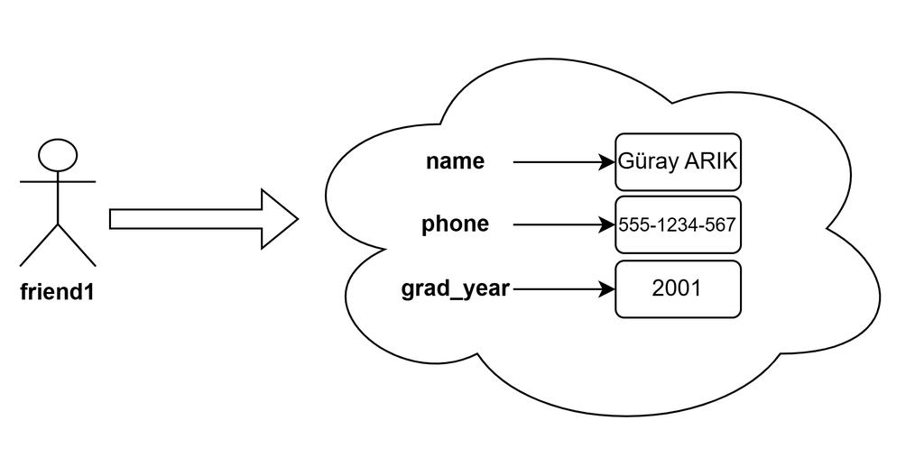

## The self Reference

The self keyword refers to the current instance of the class, allowing us to access and modify the object's data.

When the **init**() method is called, the **first parameter is always the self reference**, which points to the object being initialized.

When we call a method on an object, such as instance1.method_name(), **self refers to the object on which the method was called**.

## Defining Methods in Python

Our classes will include several methods that utilize data associated with specific instances or objects.

**Defining a method closely resembles defining a function**, with **one key distinction**: within the method body, you access instance variables through the **self parameter**.

**Every method must include the special self parameter**, which must always be listed first. This parameter refers to the object whose data is being accessed or manipulated within the method.

**While methods can accept one or more additional parameters, self must always come first** in the parameter list.

```python
class Person:
  def __init__(self, name, age):
    self.name = name
    self.age = age

  def say_hello(self):
    print("Hello my name is " + self.name)

p1 = Person("Aylin", 17)
p1.say_hello()
```

```
Hello my name is Aylin
```

## Class Special Methods

We have the ability to define and implement methods that are triggered automatically when standard Python operators `(+, -, *, /, ==, <, >, etc.)` are applied to instances of the class. This enhances the usability of objects, making interactions feel more intuitive than explicitly calling methods by their names.

**Example:** To check if two objects are equal, one might typically create a method called `is_equal()` and use it like this: if `obj1.is_equal(obj2)`. However, a more natural approach is to use the == operator. This is accomplished by defining the special method **eq**, which is invoked automatically when we compare two objects using the `==` operator.

**The `__str__()` Function** The`__str__()` function controls what should be returned when the class object is represented as a string.

If the `__str__()` function is not set, the string representation of the object is returned:

```python
class Person:
  def __init__(self, name, age):
    self.name = name
    self.age = age

p1 = Person("John", 36)

print(p1)
```

```
<__main__.Person object at 0x7aba7a4e5b50>
```

```python
class Person:
  def __init__(self, name, age):
    self.name = name
    self.age = age

  def __str__(self):
    return f"{self.name}({self.age})"

p1 = Person("John", 36)

print(p1)
```

```
John(36)
```

**string representation `(__repr__ )`**

The `__str__()` and `__repr__()` methods are both utilized to obtain a string representation of an object.

The print statement and the built-in function str() call the`__str__()` method, whereas the `repr()` function invokes the `__repr__()` method to display the object.

**What is the difference?**

**str():** Returns a **user-friendly version** of the object that is meant for display to end-users.

**repr():** Provides a **developer-friendly version** of the object, which is more suitable for debugging and typically includes more detail.

```python
class Example:
    def __str__(self):
        return "This is a user-friendly representation."

    def __repr__(self):
        return "Example()"

obj = Example()
print(str(obj))   # Calls __str__()
print(repr(obj))  # Calls __repr__()
```

```
This is a user-friendly representation.
Example()
```

```python
import datetime

today = datetime.datetime.now()

print(str(today))

print(repr(today))
```

```
2025-03-12 19:22:28.109814
datetime.datetime(2025, 3, 12, 19, 22, 28, 109814)
```

**Common Special Methods**

### Operator Methods in Python

In Python, various operators can be overridden by implementing corresponding special methods within a class. Here’s a list of common operators along with their associated method names:

| Expression | Method Name |
| --- | --- |
| x + y | __add__(self, y) |
| x - y | __sub__(self, y) |
| x * y | __mul__(self, y) |
| x / y | __truediv__(self, y) |
| x // y | __floordiv__(self, y) |
| x % y | __mod__(self, y) |
| x ** y | __pow__(self, y) |
| x == y | __eq__(self, y) |
| x != y | __ne__(self, y) |
| x < y | __lt__(self, y) |
| x <= y | __le__(self, y) |
| x > y | __gt__(self, y) |
| x >= y | __ge__(self, y) |

By defining these methods in your class, you can customize how instances of the class respond to various operators, providing a more intuitive experience when working with objects.

# Object-Oriented Programming in Python

Object-oriented programming (OOP) is a **programming paradigm** that structures programs by bundling properties and behaviors into individual objects.

For example, **an object can represent a person with attributes like name, age, and address, and behaviors such as walking and talking**. Alternatively, **an email object might have attributes like a recipient list, subject, and body, with behaviors for adding attachments or sending.**

**OOP models real-world entities and their relationships, such as cars, companies, and students.** It represents these as software objects with associated data and the ability to perform specific operations.

**OOP is based on four main principles:**

- **Encapsulation:** Bundles data (attributes) and methods (behaviors) within a class, enhancing data integrity and promoting **secure, modular code**.
- **Inheritance:** Allows subclasses to inherit attributes and methods from **parent classes**, encouraging code reuse and reducing duplication.
- **Abstraction:** Hides implementation details and reveals **only essential functionalities, simplifying interaction with objects** and focusing on their usage rather than inner workings.
- **Polymorphism:** Enables treating objects of **different types as instances of the same base type, as long as they implement a common interface**. Python’s duck typing facilitates this by allowing access to attributes and methods without concern for their actual class.

## Encapsulation

Two important principles of object-oriented programming.

**Encapsulation:** the bundling together of data attributes and the methods for operating on them. Encapsulating data and behaviors in a class allows us to enable information hiding within a class.

**Private Attributes of Objects**

To control access to an object's data, instance variables should be made private. The convention for marking an attribute as private is to prefix its name with a double underscore `(__)` followed by the variable name (e.g., `__varName`).

By using this private naming convention, users cannot directly access private data from outside the class. Instead, they should use the public interface (methods) provided by the class to interact with the private attributes.

**Types of Encapsulation**

**Public Members:** Accessible from anywhere.

**Protected Members:** Accessible within the class and its subclasses (indicated by a single underscore `_`).

**Private Members:** Accessible only within the class (indicated by a double underscore `__`).

```python
class Car:
    def __init__(self, make, model, year):
        self.make = make          # Public attribute
        self._model = model       # Protected attribute
        self.__year = year        # Private attribute

    # Public method
    def get_car_info(self):
        return f"{self.make} {self._model}, Year: {self.__year}"

    # Getter for private attribute
    def get_year(self):
        return self.__year

    # Setter for private attribute
    def set_year(self, year):
        if year > 1885:  # The first petrol car was made in 1885
            self.__year = year
        else:
            print("Invalid year!")

# Example Usage
my_car = Car("TOGG", "Model T10X", 2024)

# Accessing public member
print(my_car.make)  # Accessible

# Accessing protected member
print(my_car._model)  # Accessible but discouraged outside the class

# Accessing private member using getter
print("Car Production Year:", my_car.get_year())

# Modifying private member using setter
my_car.set_year(2022)
print(my_car.get_car_info())
```

**Explanation:**

**Public Members:** Easily accessible, such as make.

**Protected Members:** Indicated by a single underscore, such as _model. Access is discouraged outside of the class, but **allowed in subclasses**.

**Private Members:** Indicated by a double underscore, such as __year. Access requires using **getter and setter methods**.

### Getter and Setter Methods

Each class defines an interface that allows **public access to private data members**, which is part of **data encapsulation**. The designers of a class determine the level of access to give for private data.

**Instead of accessing an object's private data members directly from outside** the class, access is provided via:

**Getter Methods:** Used to retrieve the values of private data members.

**Setter Methods:** Used to update the values of private data members.

**By implementing getter and setter methods, objects can be made mutable** (allowing changes to their data) or immutable (restricting changes) based on the design of the class. This approach enhances data integrity and control over how data is manipulated.